# HUGEN 2072 Project 1 - Maleah Benn

# Instructions

Below is a tutorial consisting of a mostly-completed QC pipeline and some prompts.

Project 1 has three components:

- **Scripting/coding**: read through this file and complete the pipeline by contributing your code *where indicated*.
- **Narrative**: knit the completed .Rmd to a code-integrated HTML report of your QC process and decisions.
  - Your report must answer all the questions and perform all the tasks indicated in the instructions/prompts given for each step.
  - You must submit a successfully-knitted HTML file and the .Rmd in order to earn a passing grade for this project.
  - Set up your report to flow like an actual document you might show your supervisor to summarize the QC project, emphasizing what was done at each step rather than the code used to do it (e.g., how many samples/SNPs were filtered out at a given step?)
  - **Submit your .Rmd and HTML to Canvas**
- **Presentation**: you will make a 10-minute-maximum recording of yourself with Panopto in which you summarize this QC pipeline. Instructions will given on Canvas.

In each Part of this project you will implement one of the main steps of cleaning genotyping array data in a small dataset (note that we left a few steps out). You’ll be shown how to use functions from the `GWASTools` package, and you’ll supply a little of your own code to complete the pipeline that’s been provided. At each step, you may be asked to create a filter for the data, to address errors/discrepancies, etc. Then for each step you’ll make a short report (a few sentences and figures) explaining what you did.

Note that “sample” and “scan” are used interchangeably throughout this assignment, but that these are NOT synonymous with subject/participant/individual/etc. In this assignment, “SNP” and “probe” are used interchangeably, but in other contexts you should always remember the distinction.

**Since the pipeline below is incomplete, some of the R code chunks are set to `eval=FALSE` so that knitting to HTML will succeed. You will need to change them to `eval=TRUE` as you progress so that your knitted document shows the results of running each chunk.**

**It is expected that you will copy this file somewhere to your directory on the CRC cluster so that you can use the RStudio Server, where all the packages you need have been installed already.**

## Part 0 - Setup and Introduction to Annotation Data Frames

First, install and load the packages we’ll be using. (See https://www.bioconductor.org/install/ for installation help.)

```r
# Load the required packages for the project
# (Install them if necessary)
# Close any open GDS files before proceeding (think of this as starting off with a 'blank slate')
library("GWASTools", quietly = TRUE)
library("GWASdata", quietly = TRUE)
library("SNPRelate", quietly = TRUE)
library("dplyr", quietly = TRUE)
library("tidyverse", quietly = TRUE)
library("knitr", quietly = TRUE)
library("MASS", quietly = TRUE)
showfile.gds(closeall = T, verbose = T)
```

The array data (genotypes, intensities, and BAF/LRR information) for this project are contained in several gds files; accompanying SNP and scan annotation are also provided as an .RData file.

The probe/SNP annotation is stored in an object called a scan annotation data frame, and the sample-level annotation is stored in a scan annotation data frame. Each of these objects is similar to an ordinary data frame. More precisely, a data frame is embedded within each. There is also accompanying metadata. To access the data and metadata, the GWASTools package provides several functions. Three basic functions you should familiarize yourself with are `getAnnotation`/`pData` (extracts a standard data frame containing the annotation), `getMetadata`/`varMetadata` (extracts a data frame of variable descriptions), and `getVariableNames`/`varLabels` (extracts a vector of just the variable names). You can also view a variable in one of these objects by using `$`, as you would for an ordinary data frame. You can also add new variables, but you need to be careful to update the metadata as well. Since we will be adding new variables in the process of cleaning our data, the following chunk of code shows you how to do this. Then you will practice looking at the annotation, and your task is to answer some questions about this data set.

First, load the annotation data (`annotation_data.RData`) that was provided with this project. **You need to supply the path to this file.**

```r
# Load the probe (SNP) and sample annotation data frames, which have been saved in an .RData file
# List the loaded objects
path_to_annotation_data <- "~/2072/project1/annotation_data.RData"
load(path_to_annotation_data)
ls()
```

```
## [1] "path_to_annotation_data" "scanAnnot"
## [3] "snpAnnot"
```

Here’s a toy example showing you how to work with annotation data frames. **Read this carefully, since you’ll need to do this throughout the assignment.**

```r
# How to add a new variable to an annotation data frame
#   Make a new copy of the SNP annotation (just for this example)
#   Notice that printing the object isn't that helpful
#   So extract the annotation itself (this is the 'normal' data frame embedded in the SNP annotation data frame object)
#   Now you can see the SNP-level annotation
snp_annodf_temp <- snpAnnot
snp_annodf_temp
```

```
## An object of class 'SnpAnnotationDataFrame'
##   snps: 1 2 ... 3300 (3300 total)
##   varLabels: snpID chromosome ... rBB (14 total)
##   varMetadata: labelDescription
```

```r
snp_data_temp <- getAnnotation(snp_annodf_temp)
head(snp_data_temp)
```

```
##    snpID chromosome position      rsID alleleA alleleB  BeadSetID IntensityOnly
## 1 999447         21 13733610 rs3132407       A       G 1185447327             1
## 2 999465         21 13852569 rs2775671       T       C 1169708488             0
## 3 999493         21 14038583 rs2775018       T       C 1192445330             0
## 4 999512         21 14136579 rs3115511       T       C 1149617207             0
## 5 999561         21 14396024 rs2822404       T       C 1149961944             0
## 6 999567         21 14404476 rs1556276       A       G 1149617207             0
##           tAA       tAB       tBB       rAA       rAB       rBB
## 1 0.013743570 0.3290431 0.9184624 1.5622030 1.5927530 1.6142590
## 2 0.063259460 0.5440393 0.9796721 0.4431986 0.4431986 0.4431986
## 3 0.001315146 0.2623954 0.5362323 2.6349810 2.3149340 2.0012760
## 4 0.011004820 0.5692499 0.9846884 0.8781826 0.9453412 0.8209958
## 5 0.040206810 0.5691788 0.9902423 1.0941700 1.1270790 0.9898759
## 6 0.030895730 0.6842008 0.9837771 0.5954081 0.7681253 0.7900150
```

```r
# How to add a new variable to an annotation data frame (con't.)
#   Add a new column to the annotation (an integer dummy variable)
#   Now update the scan annotation object itself by replacing the what was in the annotation "slot"
#   You can see that the new column has been added
#   Extract the metadata so that it can be updated
#   Add a new row titled "dummy" with an appropriate labelDescription (note that the metadata is a data frame with named rows but one column)
#   Finally, replace the old metadata with the new metadata
#   Look at the data and metadata to make sure there the dummy variable has been added
snp_data_temp$dummy <- 1:nrow(snp_data_temp)
pData(snp_annodf_temp) <- snp_data_temp
head(pData(snp_annodf_temp))
```

```
##    snpID chromosome position      rsID alleleA alleleB  BeadSetID IntensityOnly
## 1 999447         21 13733610 rs3132407       A       G 1185447327             1
## 2 999465         21 13852569 rs2775671       T       C 1169708488             0
## 3 999493         21 14038583 rs2775018       T       C 1192445330             0
## 4 999512         21 14136579 rs3115511       T       C 1149617207             0
## 5 999561         21 14396024 rs2822404       T       C 1149961944             0
## 6 999567         21 14404476 rs1556276       A       G 1149617207             0
##           tAA       tAB       tBB       rAA       rAB       rBB dummy
## 1 0.013743570 0.3290431 0.9184624 1.5622030 1.5927530 1.6142590     1
## 2 0.063259460 0.5440393 0.9796721 0.4431986 0.4431986 0.4431986     2
## 3 0.001315146 0.2623954 0.5362323 2.6349810 2.3149340 2.0012760     3
## 4 0.011004820 0.5692499 0.9846884 0.8781826 0.9453412 0.8209958     4
## 5 0.040206810 0.5691788 0.9902423 1.0941700 1.1270790 0.9898759     5
## 6 0.030895730 0.6842008 0.9837771 0.5954081 0.7681253 0.7900150     6
```

```r
# How to add a new variable to an annotation data frame (con't.)
#   Extract the metadata so that it can be updated
#   View the metadata; notice every vatiable is described, except the dummy variable we just added
#   Add a new row titled "dummy" with an appropriate labelDescription (note that the metadata is just an ordinary data frame with one column, but the rows have to be named)
#   Finally, replace the old metadata with the new metadata
#   Look at the data and metadata to make sure there the dummy variable has been added
meta_temp <- getMetadata(snp_annodf_temp)
meta_temp
```

```
##                                                                                                        labelDescription
## snpID                                                                                        unique integer ID for SNPs
## chromosome    integer code for chromosome: 1:22=autosomes, 23=X, 24=pseudoautosomal, 25=Y, 26=Mitochondrial, 27=Unknown
## position                                                                    base pair position on chromosome (build 36)
## rsID                                                                                                      RS identifier
## alleleA                                                                                                         alelleA
## alleleB                                                                                                         alleleB
## BeadSetID                                                                                      BeadSet ID from Illumina
## IntensityOnly                                                              1=no genotypes were attempted for this assay
## tAA                                                                                           mean theta for AA cluster
## tAB                                                                                           mean theta for AB cluster
## tBB                                                                                           mean theta for BB cluster
## rAA                                                                                               mean R for AA cluster
## rAB                                                                                               mean R for AB cluster
## rBB                                                                                               mean R for BB cluster
## dummy                                                                                                              <NA>
```

```r
meta_temp["dummy","labelDescription"] <- "This is a dummy variable"
varMetadata(snp_annodf_temp) <- meta_temp
head(getAnnotation(snp_annodf_temp))
```

```
##    snpID chromosome position      rsID alleleA alleleB  BeadSetID IntensityOnly
## 1 999447         21 13733610 rs3132407       A       G 1185447327             1
## 2 999465         21 13852569 rs2775671       T       C 1169708488             0
## 3 999493         21 14038583 rs2775018       T       C 1192445330             0
## 4 999512         21 14136579 rs3115511       T       C 1149617207             0
## 5 999561         21 14396024 rs2822404       T       C 1149961944             0
## 6 999567         21 14404476 rs1556276       A       G 1149617207             0
##           tAA       tAB       tBB       rAA       rAB       rBB dummy
## 1 0.013743570 0.3290431 0.9184624 1.5622030 1.5927530 1.6142590     1
## 2 0.063259460 0.5440393 0.9796721 0.4431986 0.4431986 0.4431986     2
## 3 0.001315146 0.2623954 0.5362323 2.6349810 2.3149340 2.0012760     3
## 4 0.011004820 0.5692499 0.9846884 0.8781826 0.9453412 0.8209958     4
## 5 0.040206810 0.5691788 0.9902423 1.0941700 1.1270790 0.9898759     5
## 6 0.030895730 0.6842008 0.9837771 0.5954081 0.7681253 0.7900150     6
```

```r
getMetadata(snp_annodf_temp)
```

```
##                                                                                                        labelDescription
## snpID                                                                                        unique integer ID for SNPs
## chromosome    integer code for chromosome: 1:22=autosomes, 23=X, 24=pseudoautosomal, 25=Y, 26=Mitochondrial, 27=Unknown
## position                                                                    base pair position on chromosome (build 36)
## rsID                                                                                                      RS identifier
## alleleA                                                                                                         alelleA
## alleleB                                                                                                         alleleB
## BeadSetID                                                                                      BeadSet ID from Illumina
## IntensityOnly                                                              1=no genotypes were attempted for this assay
## tAA                                                                                           mean theta for AA cluster
## tAB                                                                                           mean theta for AB cluster
## tBB                                                                                           mean theta for BB cluster
## rAA                                                                                               mean R for AA cluster
## rAB                                                                                               mean R for AB cluster
## rBB                                                                                               mean R for BB cluster
## dummy                                                                                          This is a dummy variable
```

```r
rm(snp_annodf_temp, snp_data_temp, meta_temp)
```

Now we use `GdsGenotypeReader` and `GdsIntensityReader` to open the gds files that contain the array data. Then use `GenotypeData` and `IntensityData` to combine them with the SNP and sample annotation, since the functions we’ll be using later require this information to be “packaged” together.

```r
# Get the genotypes from a gds file
# Combine the genotypes with the sample and SNP annotation
genofile <- system.file("extdata", "illumina_geno.gds", package="GWASdata")
gds_geno <- GdsGenotypeReader(genofile)
genoData <- GenotypeData(gds_geno, snpAnnot=snpAnnot, scanAnnot=scanAnnot)
genoData
```

```
## An object of class GenotypeData
##  | data:
## File: /ihome/crc/install/gcc-8.2.0/r/4.0.0/lib64/R/library/GWASdata/extdata/illumina_geno.gds (94.0K)
## +    [  ]
## |--+ sample.id   { Int32 77 ZIP(42.2%), 130B }
## |--+ snp.id   { Int32 3300 ZIP(38.5%), 5.0K }
## |--+ snp.chromosome   { UInt8 3300 ZIP(1.15%), 38B } *
## |--+ snp.position   { Int32 3300 ZIP(91.0%), 11.7K }
## |--+ snp.rs.id   { VStr8 3300 ZIP(38.4%), 12.5K }
## |--+ snp.allele   { VStr8 3300 ZIP(9.49%), 1.2K }
## \--+ genotype   { Bit2 3300x77, 62.0K } *
##  | SNP Annotation:
## An object of class 'SnpAnnotationDataFrame'
##   snps: 1 2 ... 3300 (3300 total)
##   varLabels: snpID chromosome ... rBB (14 total)
##   varMetadata: labelDescription
##  | Scan Annotation:
## An object of class 'ScanAnnotationDataFrame'
##   scans: 1 2 ... 77 (77 total)
##   varLabels: scanID subjectID ... file (13 total)
##   varMetadata: labelDescription
```

```r
# Get the intensity data from a gds file
# Combine with the sample and SNP annotation
qxyfile <- system.file("extdata", "illumina_qxy.gds", package="GWASdata")
gds_qxy <- GdsIntensityReader(qxyfile)
qxyData <- IntensityData(gds_qxy, snpAnnot=snpAnnot, scanAnnot=scanAnnot)
qxyData
```

```
## An object of class IntensityData
##  | data:
## File: /ihome/crc/install/gcc-8.2.0/r/4.0.0/lib64/R/library/GWASdata/extdata/illumina_qxy.gds (1.0M)
## +    [  ]
## |--+ sample.id   { Int32 77 ZIP(42.2%), 130B }
## |--+ snp.id   { Int32 3300 ZIP(38.5%), 5.0K }
## |--+ snp.chromosome   { UInt8 3300 ZIP(1.15%), 38B } *
## |--+ snp.position   { Int32 3300 ZIP(91.0%), 11.7K }
## |--+ snp.rs.id   { VStr8 3300 ZIP(38.4%), 12.5K }
## |--+ quality   { Float32 3300x77 ZIP(4.93%), 48.9K }
## |--+ X   { Float32 3300x77 ZIP(50.3%), 498.8K }
## \--+ Y   { Float32 3300x77 ZIP(49.4%), 490.5K }
##  | SNP Annotation:
## An object of class 'SnpAnnotationDataFrame'
##   snps: 1 2 ... 3300 (3300 total)
##   varLabels: snpID chromosome ... rBB (14 total)
##   varMetadata: labelDescription
##  | Scan Annotation:
## An object of class 'ScanAnnotationDataFrame'
##   scans: 1 2 ... 77 (77 total)
##   varLabels: scanID subjectID ... file (13 total)
##   varMetadata: labelDescription
```

```r
# Get the BAF/LRR data from a gds file
# Combine with the sample and SNP annotation
blfile <- system.file("extdata", "illumina_bl.gds", package="GWASdata")
gds <- GdsIntensityReader(blfile)
blData <- IntensityData(gds, snpAnnot=snpAnnot, scanAnnot=scanAnnot)
blData
```

```
## An object of class IntensityData
##  | data:
## File: /ihome/crc/install/gcc-8.2.0/r/4.0.0/lib64/R/library/GWASdata/extdata/illumina_bl.gds (1.1M)
## +    [  ]
## |--+ sample.id   { Int32 77 ZIP(42.2%), 130B }
## |--+ snp.id   { Int32 3300 ZIP(38.5%), 5.0K }
## |--+ snp.chromosome   { UInt8 3300 ZIP(1.15%), 38B } *
## |--+ snp.position   { Int32 3300 ZIP(91.0%), 11.7K }
## |--+ snp.rs.id   { VStr8 3300 ZIP(38.4%), 12.5K }
## |--+ BAlleleFreq   { Float32 3300x77 ZIP(40.9%), 405.8K }
## \--+ LogRRatio   { Float32 3300x77 ZIP(68.2%), 676.6K }
##  | SNP Annotation:
## An object of class 'SnpAnnotationDataFrame'
##   snps: 1 2 ... 3300 (3300 total)
##   varLabels: snpID chromosome ... rBB (14 total)
##   varMetadata: labelDescription
##  | Scan Annotation:
## An object of class 'ScanAnnotationDataFrame'
##   scans: 1 2 ... 77 (77 total)
##   varLabels: scanID subjectID ... file (13 total)
##   varMetadata: labelDescription
```

## Part 0 - Report

Using the functions introduced above to help you, briefly describe the dataset in a few sentences. Answer the following questions. Whatever code you use to help answer these questions can go in the empty chunk that follows.

- What is the difference between the scanID and subjectID variables? Why are they both provided?
- How many families are represented, and how many samples are from each family?
- How many samples are of each sex?
- How many samples are from each population group?
- How many samples are there? How many people did they come from?
- How many SNPs are there?
- Which chromosomes are represented? How many SNPs are on each?

```r
# Q1
varMetadata(scanAnnot)

# Q2
head(scanAnnot@data)
n_distinct(scanAnnot@data$family)

scansperfam <- scanAnnot@data %>% count(family) %>% kable(caption = "Q0.2: scanIDs per family", format = "simple", align = "lr")

# Q3
scansbysex <- scanAnnot@data %>% count(sex) %>% kable(caption = "Q0.3: scanIDs by sex", format = "simple", align = "lr")

# Q4
scansbyrace <- scanAnnot@data %>% count(race) %>% kable(caption = "Q0.4: scanIDs by race", format = "simple", align = "lr")

# Q5
n_distinct(scanAnnot@data$scanID)
n_distinct(scanAnnot@data$subjectID)

# Q6
head(snpAnnot@data)
n_distinct(snpAnnot@data$snpID)

# Q7
snpsperchrom <- snpAnnot@data %>% count(chromosome) %>% kable(caption = "Q0.7: snp IDs per chromosome", format = "simple", align = "lr")
```

## **Part 0 Report**

In this dataset, there are 77 total samples coming from 43 unique subjectIDs. The scanID represents the unique ID for each scan while the subjectID is the subject identified. A single subject could have multiple scans so both need to be included. In this dataset, there are 13 unique family IDs with the number of scanIDs per family shown in Table Q0.2 below.

```r
scansperfam
```

Q0.2: scanIDs per family

| family | n |
| --- | --- |
| 4 | 5 |
| 5 | 6 |
| 9 | 5 |
| 12 | 5 |
| 28 | 5 |
| 58 | 2 |
| 1334 | 6 |
| 1340 | 5 |
| 1341 | 9 |
| 1344 | 6 |
| 1347 | 6 |
| 1362 | 11 |
| 1408 | 6 |

There are 35 individuals with sex reported as ‘F’ and 42 individuals reported as sex ‘M’ as shown in Table Q0.3.

```r
scansbysex
```

Q0.3: scanIDs by sex

| sex | n |
| --- | --- |
| F | 35 |
| M | 42 |

There are 49 individuals with reported race of ‘CEU’ and 28 individuals with reported race of ‘YRI’ as shown in Table Q0.4. HapMap population group abbreviations used where ‘CEU’ designates Utah residents with Northern and Western European ancestry and ‘YRI’ designates Yoruban individuals in Ibadan, Nigeria.

```r
scansbyrace
```

Q0.4: scanIDs by race

| race | n |
| --- | --- |
| CEU | 49 |
| YRI | 28 |

There are 3,300 unique SNPs coming from six chromosomes (21 - 26) in the dataset as shown in Table Q0.7 where chromosomes 21-23 have 1,000 SNPs each and chromosomes 24-26 have 100 SNPs each.

```r
snpsperchrom
```

Q0.7: snp IDs per chromosome

| chromosome | n |
| --- | --- |
| 21 | 1000 |
| 22 | 1000 |
| 23 | 1000 |
| 24 | 100 |
| 25 | 100 |
| 26 | 100 |

## Part 1 - Missing Call Rate for Samples and SNPs

The basic GWASTools functions for missingness are `missingGenotypeBySnpSex` and `missingGenotypeByScanChrom`. `missingGenotypeBySnpSex` returns a list of three objects: `missing.counts`, `scans.per.sex`, and `missing.fraction`. Read the help file for this function so that you understand what information is contained in these and how the Y chromosome is treated by sex (where sex is as defined in the scan annotation). Similarly, `missingGenotypeByScanChrom` returns `missing.counts`, `snps.per.chr`, and `missing.fraction`.

There are four basic missingness calculations to be done, in the following order.

1. Calculate `missing.n1` = fraction of genotype calls missing over all samples (except that females are excluded for Y chr SNPs)
2. Calculate `missing.e1` = missing call rate per sample over all SNPs (excluding SNPs with all calls missing)
3. Calculate `missing.n2` = call rate per SNP over all samples whose `missing.e1` is less than `0.05`
4. Calculate `missing.e2` = missing call rate per sample over all SNPs with `missing.n2` values less than `0.05`

We’ll want to store the missingness information in the annotation data frames as we proceed.

Here’s how to calculate and store missing.n1.

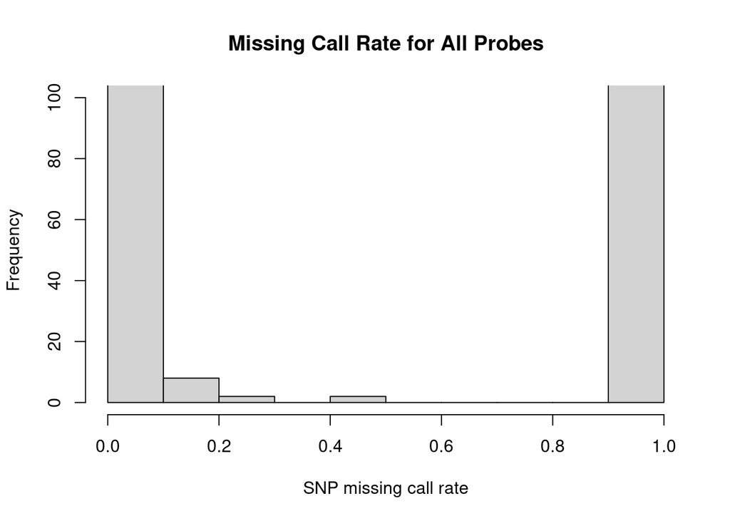

```r
# Using missingGenotypeBySnpSex to calculate missing.n1
#   First look at some of the results
#   We want to add the missingness per SNP as a new column to snpAnnot
#   Fist we should make sure the snpIDs are in the same order in the annotation and in the missingness report (miss$missing.fraction); they are
#   Then go ahead and add missing.n1 as a new annotation data column, and update the metadata
miss <- missingGenotypeBySnpSex(genoData)
names(miss)
head(miss$missing.counts)
miss$scans.per.sex
head(miss$missing.fraction)
allequal(snpAnnot$snpID, as.numeric(names(miss$missing.fraction)))
snpAnnot$missing.n1 <- miss$missing.fraction
varMetadata(snpAnnot)["missing.n1", "labelDescription"] <- paste("fraction of genotype calls missing over all samples, except that females are excluded for Y chr SNPs")

# Explore the missing call rate per probes a little more
#   Look at the distribution of missingness for all the probes
#   How many SNPs are missing a genotype for every single sample? Apparently there are 151 such SNPs
hist(snpAnnot$missing.n1, ylim=c(0,100), xlab="SNP missing call rate", main="Missing Call Rate for All Probes")
```

```r
sum(snpAnnot$missing.n1 == 1)
```

Now we calculate and store missing.e1. The steps are described in the comments below.

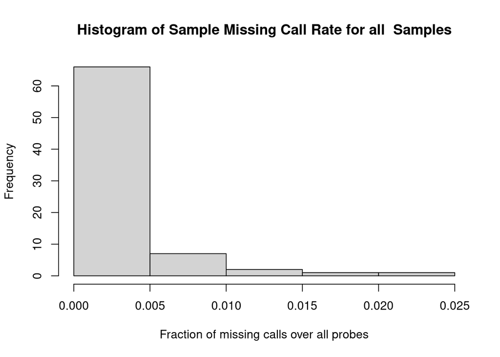

```r
# Using missingGenotypeByScanChrom to calculate missing.e1
#   Store a vector containing the snpIDs of all the SNPs with missing call rate of 100%
#   Count how many there are
#   Apply missingGenotypeByScanChrom to genoData, using the snp.exclude option to exclude these SNPs (why does it make sense to exclude those SNPs?)
#   Make sure the order of the scanIDs in the output from missingGenotypeByScanChrom is the same as the order of the scanIDs in the annotation data frame
#   Make a new column in scanAnnot called missing.e1 and store the per-scan missingness from missingGenotypeByScanChrom there
#   Update the scanAnnot metadata
sum(snpAnnot$missing.n1 == 1)
snpexcl <- snpAnnot$snpID[snpAnnot$missing.n1 == 1]
miss <- missingGenotypeByScanChrom(genoData, snp.exclude=snpexcl)
allequal(names(miss$missing.fraction), scanAnnot$scanID)
scanAnnot$missing.e1 <- miss$missing.fraction
varMetadata(scanAnnot)["missing.e1", "labelDescription"] <- "fraction of genotype calls missing over all snps with missing.n1<1 except that Y chr SNPs are excluded for females"


# We can check summary statistics and make a histogram, too
summary(scanAnnot$missing.e1)
hist(scanAnnot$missing.e1, xlab="Fraction of missing calls over all probes",main="Histogram of Sample Missing Call Rate for all  Samples")
```

Now, supply your code to calculate and store missing.n2. The steps you should follow are described in the comments below.

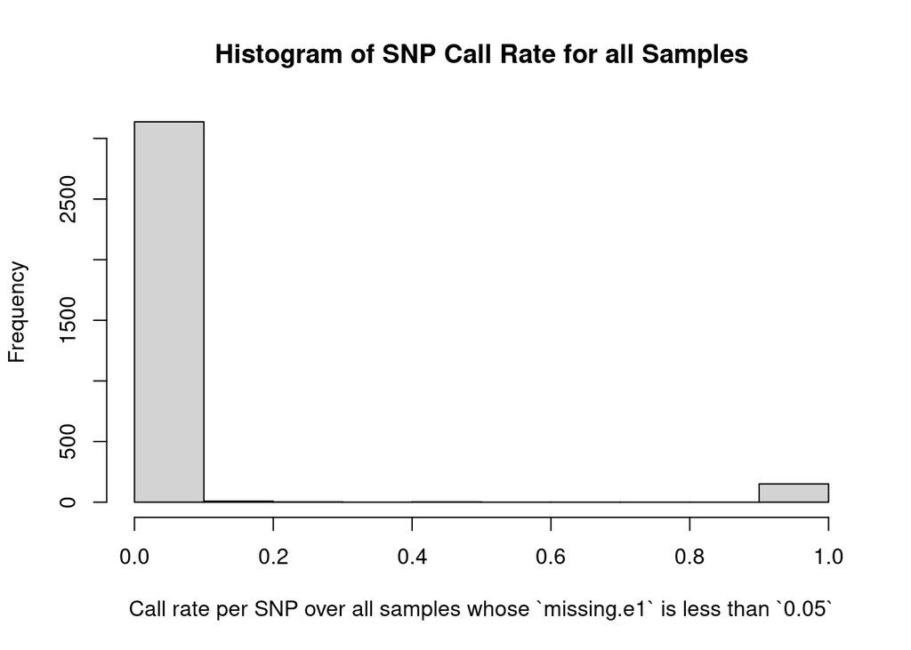

```r
# Now that missing.n1 and missing.e1 have been calculated, we can calculate missing.n2
#   Recall that missing.n2 = call rate per SNP over all samples whose missing.e1 is less than 0.05
#   Since no sample had missing.e1 > 0.05 in this dataset, we don't actually have to exclude any samples
#   However, let's proceed as if there were some samples with missing.e1 > 0.05
#   Make a vector of the scanIDs for the samples with high missing.e1
#   Apply the missingGenotypeBySnpSex function again, using the scan.exclude argument
#   Store missing.n2 as a new column in snpAnnot
#   Update the metadata for snpAnnot!
#   The labelDescription for missing.n2 should be "fraction of genotype calls missing over all samples with missing.e1<0.05 except that females are excluded for Y chr SNPs"

# scanIDs to exclude where e1 is greater than or equal to 0.05
scans.exc <- scanAnnot$scanID[scanAnnot$missing.e1 >= 0.05]

# see how many samples are excluded
length(scans.exc)

# exclude scans from miss and save as updated version
miss2 <- missingGenotypeBySnpSex(genoData, scan.exclude=scans.exc)

# store missing.n2
snpAnnot$missing.n2 <- miss2$missing.fraction

# IQR
summary(snpAnnot$missing.n2)
length(snpAnnot$missing.n2 == 0)

# update metadata descriptions
varMetadata(snpAnnot)["missing.n2", "labelDescription"] <- paste("fraction of genotype calls missing over all samples with missing.e1<0.05 except that females are excluded for Y chr SNPs")

# histogram
n2_hist <- hist(snpAnnot$missing.n2, xlab="Call rate per SNP over all samples whose `missing.e1` is less than `0.05`", main="Histogram of SNP Call Rate for all Samples")
```

Write code to calculate and store missing.e2. The steps you should follow are described in the comments below.

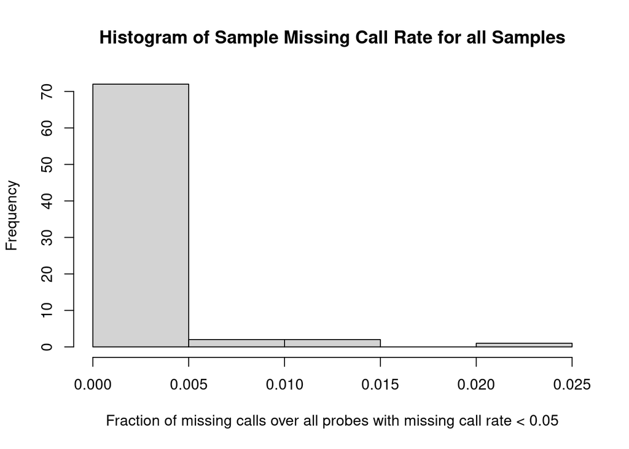

```r
# Last, we calculate missing.e2
#   Recall missing.e2 = missing call rate per sample over all SNPs with missing.n2 values less than 0.05
#   Store a vector with the snpIDs of all probes with missing.n2 >= 0.05
#   Apply missingGenotypeByScanChrom to genoData again, using the snp.exclude argument to exclude the SNPs with missing.n2 >= 0.05 (why do we do this?)
#   Make a new column in scanAnnot called missing.e2 to store the missingness per-scan you just calculated
#   Update the scanAnnot metadata
#   The labelDescription should say "fraction of genotype calls missing over all snps with missing.n2<0.05 except that Y chr SNPs are excluded for females"

# snps to exclude where missing.n2 greater than or equal to 0.05
snps.exc <- snpAnnot$snpID[snpAnnot$missing.n2 >= 0.05]

# see how many snps to be excluded
length(snps.exc)

# exclude the snps
miss3 <- missingGenotypeByScanChrom(genoData, snp.exclude=snps.exc)

# store missing.e2
scanAnnot$missing.e2 <- miss3$missing.fraction

# IQR
summary(scanAnnot$missing.e2)

# update metadata descriptions
varMetadata(scanAnnot)["missing.e2", "labelDescription"] <- paste("fraction of genotype calls missing over all snps with missing.n2<0.05 except that Y chr SNPs are excluded for females")

# how many scans had MCR of 0 (no missing calls)
sum(scanAnnot$missing.e2 == 0)

# histogram of missing.e2
e2_hist <- hist(scanAnnot$missing.e2, xlab="Fraction of missing calls over all probes with missing call rate < 0.05", main="Histogram of Sample Missing Call Rate for all Samples")
```

## Part 1 - Report

Summarize the filtering you’ve accomplished at this step. Include the following in your answer the following questions.

- (First, make sure you’ve filled in the calculations of missing.n2 and missing.e2 in the chunks above.)
- How many SNPs and samples were genotyped?
- Briefly describe the purpose of doing this step in two rounds (why do we calculate both missingnesses twice?)
- What were the median, mean, and maximum per-sample missingness (use missing.e2)? Make a histogram of missing.e2.
- How many samples had no missing calls at all (use missing.e2)?
- Are the samples generally “good”? How many should be excluded from downstream analyses?
- How many SNPs had a 100% missing call rate (use missing.n1)?
- What are the median, mean, and maximum per-SNP missingnesses (use missing.n2)? How many SNPs are missing no calls at all?
- Make a histogram of missing.n2
- How many SNPs are filtered out and how many remain if you retain only SNPs with missing.n2 < 0.05?
- Make a histogram showing missing.n2 for the remaining SNPs

## **Part 1 Report**

Missingness is performed in two rounds: the first to remove samples and SNPs with gross missingness which is indicative of a bad probe or poor sample handling. Then, once those are removed, the exclusion criteria is refined to remove any SNPs or samples of poor quality prior to analyses. Performing two rounds ensures that only the highest quality SNP and sample measurements are included in analyses.

Per sample missingness median, mean, and maximum are 0.07%, 0.2%, and 2.5%, respectively. There were 6 samples with an MCR of 0. A total of 151 SNPs had a 100% missing call rate and will be excluded from future analyses.

```r
n2_hist
```

[output not shown]

```r
e2_hist
```

## Part 2 - Allelic Imbalance; BAF and LRR Plots

Here we want to look at B allele frequency (BAF) and log R ratio (LRR) plots using `chromIntensityPlot`. Ordinarily, since there are 22-23 chromosomes to check for every sample, you would use a script that automatically detects aberrations in BAF and LRR. For this project, we’ll pretend that our pipeline has already flagged one sample for a possible chromosomal anomaly.

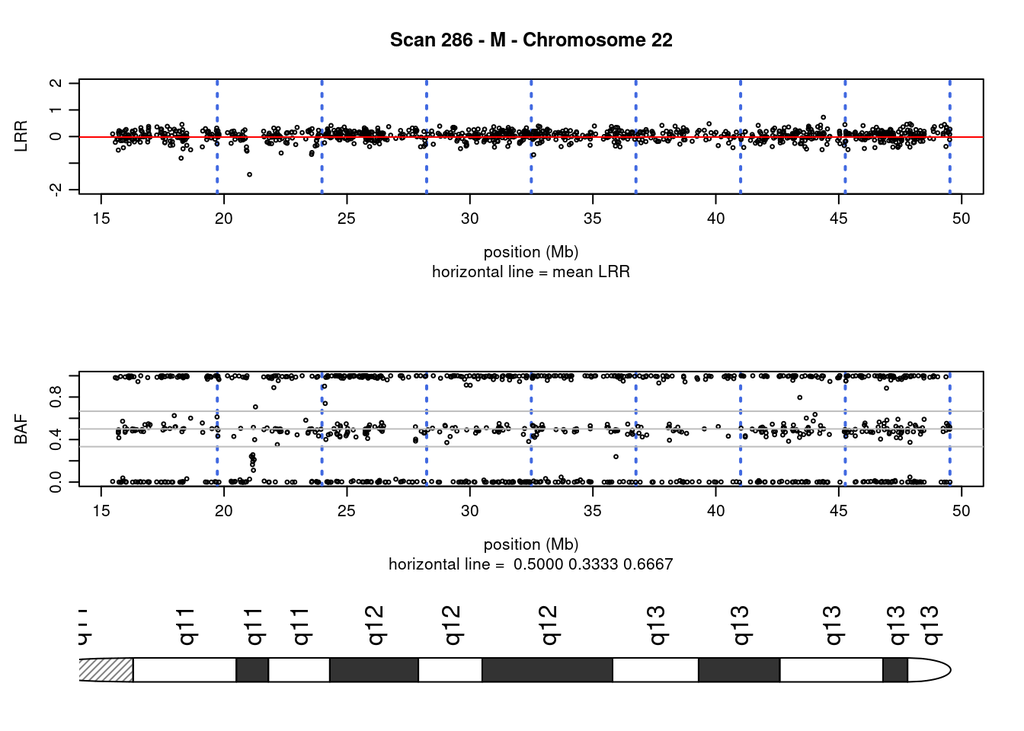

```r
# Recall that earlier we read the intensity data into an IntensityData object called blData
# The snp/scan annotation were attached as well
# Suppose that chromosome 22 was flagged for scanID 286
# Making the BAF/LRR plot is easy
#dev.off()
chromIntensityPlot(blData, scan.ids=286, chrom.ids=22)
```

```r
par(mfrow=c(1,1))
```

## Part 2 - Report

- Describe the purpose of this step.
- Show an example of a “normal” pair of BAF/LRR plots (choose any chromosome/scanID you want).
- How would you detect trisomy 21 (i.e., describe briefly in words what the BAF/LRR plot would look like).
- Suppose an individual had a balanced reciprocal translocation involving chromosome 2 and 4. What would you expect that individual’s BAF/LRR plots would look like for those chromosomes?
- Suppose chromosome 22 in sample 286 was the only chromosome flagged for a possible anomaly in this dataset. Looking at the plot, do you notice anything strange? Can you suggest what kind of anomaly might be showing up? (There isn’t any single answer that’s certainly right! The purpose of this question is to check that you understand what the BAF and LRR plots “mean”).
- Finally, suppose your pipeline has given you a list of the exact chromosomal segments showing possibly aneuploidies/anomalies in each sample. What would you recommend doing with the genotypes in those segments? (You’re not being asked to implement this here - just say what you recommend doing.)

## **Part 2 Report**

Looking at flagged samples for possible allele imbalance is important because anomalies can cause issues in downstream statistical analyses if you’re expecting each SNP to have two alleles. A normal LRR/BAF pair is shown below for scan 293 on chromosome 23 (X chromosome).

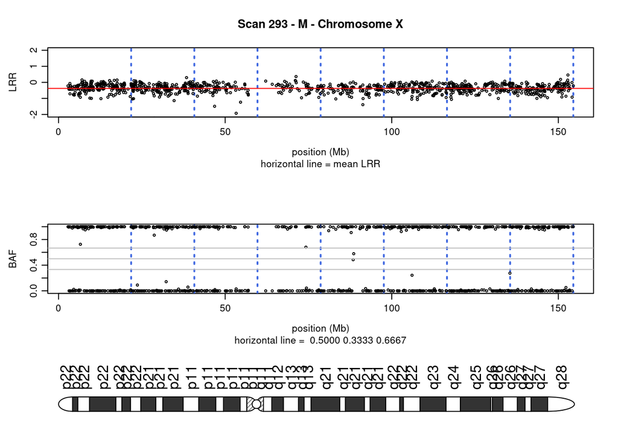

This participant has a reported sex of ‘male’ and chromosome 23 is the X chromosome. Since biologically male individuals only have one copy of the X chromosome, we see that the mean LRR for sample 293 is slightly less than zero. Additionally, the BAF plot for this scan shows a loss of heterozygosity across the entire chromosome - again, to be expected as this sample has only one X chromosome and therefore can only be homozygous at any given location.

To detect any trisomy (although trisomy 21 is the most common in humans that live to adulthood), you could inspect the LRR and BAF plots. The mean line of the LRR would be shifted up (above zero) across the whole chromosome (or portion of the duplication). The BAF plot would have 4 distinct bands as opposed to the ‘standard’ three bands at 0.0, 0.5, and 1.0. The bands on the BAF plot in a trisomy individual would cluster around 0.0 (AAA), 0.33 (AAB), 0.67 (ABB), and 1.0 (BBB).

Individuals with a balanced reciprocal translocation are generally phenotypically “normal”. Since the transolcation is balanced, you would not see an increase (indicating a duplication) or a decrease (indication a deletion) on the LRR plot. The BAF plot for an individual with a balanced reciprocal translocation would also appear “normal” with three bands clustered around 0.0, 0.5, and 1.0. This is because there is no gain or loss of genetic material and no loss of heterozygosity. Both plots would appear normal in this instance.

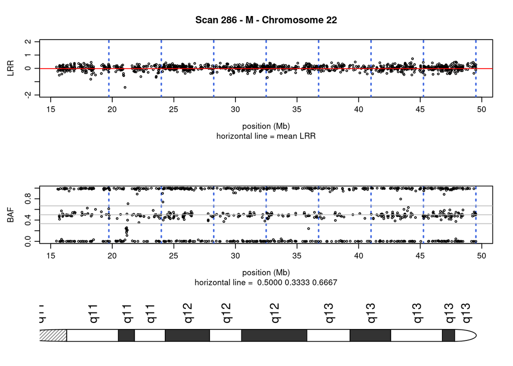

From the BAF plot for sample 286 chromosome 22, it looks like there are a few small LOH runs; one from ~26-27 Mb, ~37-38 Mb, ~45 Mb, and ~49 Mb. In these areas there are still data points at both 0.0 and 1.0, but no points near the 0.5 band, indicating a loss of heterozygosity. Additionally, when looking at these same areas of the chromosome on the LRR plot, we do not see any shift in intensity. If the LRR had shifted down, that would indicate a deletion as opposed to a LOH. However, the LRR remains near 0.0, supporting the LOH theory. Additionally, near the 22 Mb mark, there is a gap in the LRR plot and a corresponding lack of clustering at the same position in the BAF. Maybe this is due to bad probes in this area of the chromosome.

First, you would want to visually inspect the LRR/BAF plots for each of the flagged samples. If you can determine what is going on (i.e. run of homozygosity due to recent consanguineous mating) and any anomalies in these segments do not interfere with your phenotype of interest, the sample can be left in the analyses. If anomalies cannot be resolved or it appears that there are true deletions, duplications, or contaminations, you would likely want to remove those samples from your analyses.

## Part 3 - Inferred vs. Reported Sex and Relatedness

To investigate discrepancies in inferred vs. reported sex (and, possibly, sex chromosome aneuploidies), we will produce four plots that summarize each scan’s heterozygosity and intensity for the sex chromosomes:

1. Mean Y chromosome vs. mean X chromosome intensity
2. Mean X chromosome heterozygosity vs. mean X chromosome intensity
3. Mean Y chromosome intensity vs. mean X chromosome heterozygosity
4. Mean X chromosome heterozygosity vs. autosomal heterozygosity

Recall that the intensity data was read in earlier as `qxyData`. Before making our graphs, we’ll need to calculate the variables we want to plot. The basic function we’ll use to do this is `meanIntensityByScanChrom`, which will return a list of matrices. Read the help file of this function so that you understand the output. Heterozygosity is calculated with `hetByScanChrom`.

[figure not shown]

```r
# Look at the structure of the IntensityData object
# For each probe, there's a numerical ID, chromosome, position, rsID
# The intensities (stored as variables called X and Y) are each essentially 3300x77 matrices (an X and Y intensity for each scan for every single probe)
# (Don't confuse the *intensity variable names* X and Y in the IntensityData object with the X and Y *chromosomes*!)
# Apply the meanIntensityByScanChrom function to get the intensity averages
# (We're not going to use all of the output from this function)
# Extract the matrix containing the mean intensity for each chromosome for each scan
# The matrix is 77x6 since there are 77 samples and 6 chromosomes represented in the dataset
qxyData
inten.by.chrom <- meanIntensityByScanChrom(qxyData)
names(inten.by.chrom)
mninten <- inten.by.chrom$mean.intensity
dim(mninten)
head(mninten)

# We also need to calculate the X chromosome and autosome heterozygosities for each sample before we can plot them
# Apply hetByScanChrom to genoData (we need actual genotypes to calculate the heterozygosity)
# The function calculates eachs scan's heterozygosity for each chromosome, and also for the autosomes as a whole
# We want to add X and autosome heterozygosity as new columns in scanAnnot
# Make sure the scanIDs are in the right order first! (they are)
# Extract the autosomal and X heterozygosity and store them in scanAnnot
# Add appropriate metadata
het.results <- hetByScanChrom(genoData)
allequal(scanAnnot$scanID, rownames(het.results))
scanAnnot$het.A <- het.results[,"A"]
scanAnnot$het.X <- het.results[,"X"]
varMetadata(scanAnnot)["het.A", "labelDescription"] <- "fraction of heterozygotes for autosomal SNPs"
varMetadata(scanAnnot)["het.X", "labelDescription"] <- "fraction of heterozygotes for X chromosome SNPs"

# Before making the plots, there are a few things to do
# We want to color the plotted points by annotated sex
# But first, make sure that the order of the scanIDs (and hence the annotated sexes) matches the order of the scanIDs in the data we'll plot
# Now we assign each sex a color (male=blue, female=red)
# Store the colors in a vector
# We also want to count the number of SNPs getting included on the X and Y chromosomes (which are coded as 23 and 25 in snpAnnot)
allequal(scanAnnot$scanID, rownames(mninten))
xcol <- rep(NA, nrow(scanAnnot))
xcol[scanAnnot$sex == "M"] <- "blue"
xcol[scanAnnot$sex == "F"] <- "red"
nx <- sum(snpAnnot$chromosome == 23)
ny <- sum(snpAnnot$chromosome == 25)

# Now make the plots
# All intensities
x1 <-mninten[,"X"]
y1 <- mninten[,"Y"]
main1 <- "Mean X vs \nMean Y Chromosome Intensity"
# Het on X vs X intensity
x2 <- mninten[,"X"]
y2 <- scanAnnot$het.X
main2 <- "Mean X Chromosome Intensity vs Mean X Chromosome Heterozygosity"
# Het on X vs Y intensity
y3 <- mninten[,"Y"]
x3 <- scanAnnot$het.X
main3 <- "MeanX Chromosome Heterozygosity vs Mean Y Chromosome Intensity"
# X vs A het
x4 <- scanAnnot$het.A[scanAnnot$sex == "F"]
y4 <- scanAnnot$het.X[scanAnnot$sex == "F"]
main4 <- "Mean Autosomal Heterozygosity vs Mean X Chromosome Heterozygosity"
# Make labels for axes/legends
cols <- c("blue","red")
mf <- c("male", "female")
xintenlab <- paste("X intensity (n=", nx, ")", sep="")
yintenlab <- paste("Y intensity (n=", ny, ")", sep="")
```

## Part 3a - Report (Sex Check)

- Describe any anomalies you see in the 4 plots above.
- Figure out the scanIDs of any scans that look like outliers or possible instances of mislabeled sex. Include these IDs in your report and describe why they appear to be mislabeled.
- For the purposes of this assignment we will ASSUME that some scans have just had their sexes mislabeled. (In “real life”, we would not just assume this, and we might instead flag these scans for removal from some downstream steps/analyses.)
- Manually change the sex annotation for these scans in scanAnnot to “remove” the discrepancy. (Manually changing your data is risky and not generally recommended. Be careful!). In your report, state exactly what changes you made. Add a new column to scanAnnot indicating this, too (add appropriate metadata). Does anything in the pedigree structure make you more confident that this “fix” is correct? (Are these samples labeled as mothers or fathers?)
- Remake the 4 plots above, using the “corrected”" data (nothing should appear mislabeled now for this dataset).
- How might you follow up on this “in real life”?

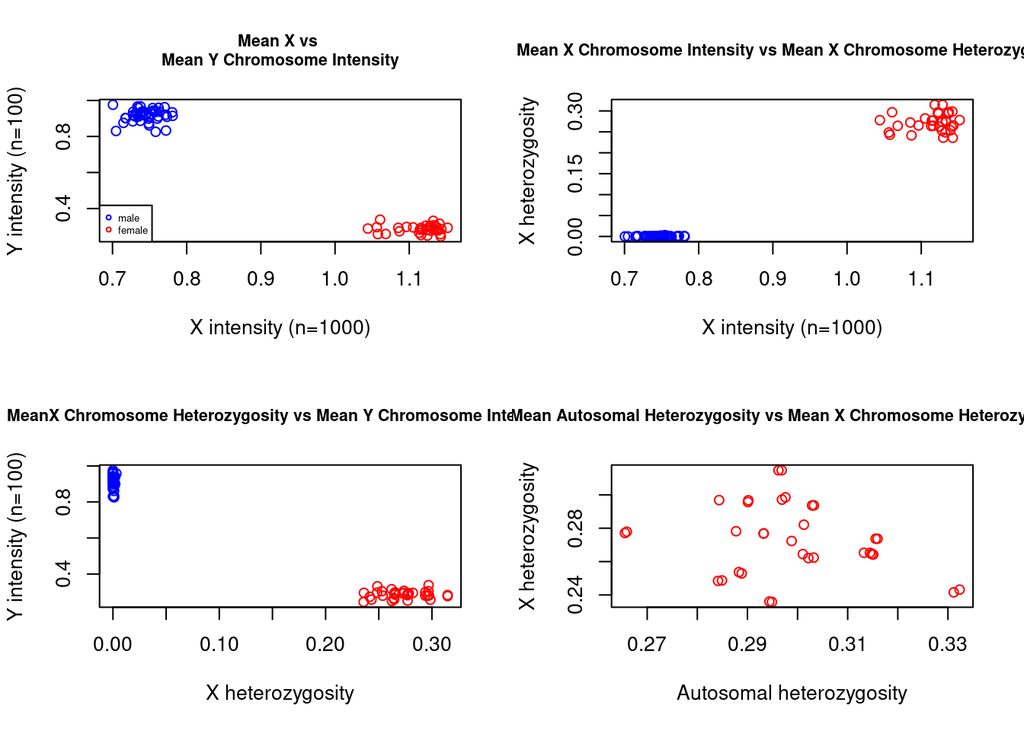

```r
# which scanIDs are discordant
## subset dataframe
sexcheck <- scanAnnot@data[,c("scanID","sex","het.X")]

## look at dataframe
head(sexcheck, n=50)
dim(sexcheck)

## filter for discordant reported sex (reported "F" but low X heterozygosity)
disc_sex <- filter(sexcheck, sex=="F" & het.X < 0.05)
head(disc_sex)

# change sex annotation in 325 and 326 to resolve discordance
## add updated_sex column
scanAnnot$updated_sex <- scanAnnot@data$sex

## check
head(scanAnnot@data)

## manually change updated_sex for scanIDs 325 and 326 to "M"
pData(scanAnnot)$updated_sex[pData(scanAnnot)$scanID == 325 | pData(scanAnnot)$scanID == 326] <- "M"

## check
scanAnnot@data %>% filter(scanID == 325)

## update metadata descriptions
varMetadata(scanAnnot)["updated_sex", "labelDescription"] <- paste("reported sex updated to reflect inferred sex")

# new plots
## change column where reported sex is coming from
allequal(scanAnnot$scanID, rownames(mninten))
xcol2 <- rep(NA, nrow(scanAnnot))
xcol2[scanAnnot$updated_sex == "M"] <- "blue"
xcol2[scanAnnot$updated_sex == "F"] <- "red"

x4.2 <- scanAnnot$het.A[scanAnnot$updated_sex == "F"]
y4.2 <- scanAnnot$het.X[scanAnnot$updated_sex == "F"]

## plot
par(mfrow=c(2,2))
plot(x1, y1, xlab=xintenlab, ylab=yintenlab,main=main1, col=xcol2, cex.main=0.8)
legend("bottomleft",mf,col=cols,pch=c(1,1), cex=0.5)
plot(x2, y2, col=xcol2, xlab=xintenlab, ylab="X heterozygosity", main=main2, cex.main=0.8)
plot(x3, y3, col=xcol2, ylab=yintenlab, xlab="X heterozygosity", main=main3, cex.main=0.8)
plot(x4.2, y4.2, col="red", xlab="Autosomal heterozygosity", ylab="X heterozygosity", main=main4, cex.main=0.8)
```

```r
par(mfrow=c(1,1))
```

## **Part 3a Sex Check Report**

Potential anomalies:

- Plot 1: There are a few samples (maybe 2) that have a discordance between reported and inferred sex. The data points are colored by reported sex but plotted based on inferred. There are two data points that are colored red (indicating a reported sex of female) while clustering with the male inferred sex.
- Plot 2: Again, there is at least one sample that has a reported sex of female (red color) that is clustering with the rest of the inferred male samples.
- Plot 3: At least one reported female sample is clustering with the inferred male cluster.
- Plot 4: There appears to be two outliers near the 0.0 X heterozygosity position on this plot which may be indicative of an individual who is XY or XO (inferred) but reported a sex of ‘female’ (biologically, XX). This could be a reporting error or an identity discordance.

ScanIDs 325 and 326 are discordant where the reported sex (F) does not align with their X heterozygosity calculations. Individuals who are biologically female (XX) will have a higher X heterozygosity than biologically male (XY) individuals. Therefore, scanIDs whose sex is recorded as “F” but whose X heterozygosity is less than 5% are likely discordant. Additionally, scanIDs 325 and 326 are listed as being the father of scanIDs 294 and 295. This pedigree information confirms that the reported sex of ‘female’ was erroneous. The updated plots are shown below.

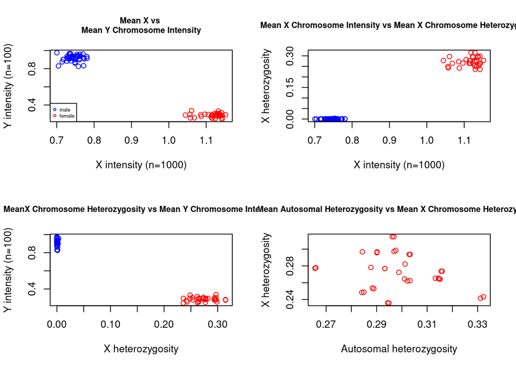

To follow up on sex discordance, first check to see if the reported sex was entered in error. Confirm with the person who entered in the data and use other documentation to see what reported sex is listed for discordant samples. Additionally, I would check with pedigree information to see if the discordance can be resolved. If the reported sex discrepancy cannot be resolved via additional documentation, the sample should be excluded from downstream analyses.

## Part 3b - Relatedness

Next, we estimate the identity-by-descent (IBD) coefficients for each pair of scans in order to describe genetic relatedness. There are various methods for doing this. We’ll use the KING method, implemented in the `SNPRelate` package. The `pedigreeCheck` function will help us look for errors in the pedigree (i.e., the reported relationships) before comparing reported vs. genetic relatedness. Look at the help menu for this function to see what kinds of inconsistencies it reports on. Then `pedigreePairwiseRelatedness` will calculate the expected genetic relatedness for each pair of subjects, based on the reported pedigree structure.

```r
# Close the connection to the genotypes gds file (recall that we changed the sexes in the previous step, so we should "remake" genoData with the updated annotation)
# Re-open the data and apply snpgdsIBDKING to calculate relatedness statistics
# Let's use the snp.id argument to include only "good" SNPs in the calculation (missing.n2 < 0.05)
# The IBD object returned is a list containing scanIDs, snpIDs, and two relatedness matrices
# Observe that monomorphic and non-autosomal SNPs are also being excluded by default
# Recall that the relatedness matrices are symmetric 77x77 matrices (the entry in row i, column j is the coefficient for samples i and j)
close(genoData)
gds_geno <- system.file("extdata", "illumina_geno.gds", package="GWASdata")
snps_to_include_for_kinship <- snpAnnot$snpID[snpAnnot$missing.n1 < 0.05]
gdsobj <- snpgdsOpen(gds_geno)
ibdobj <- snpgdsIBDKING(gdsobj, snp.id=snps_to_include_for_kinship)
snpgdsClose(gdsobj)
dim(ibdobj$kinship)
ibdobj$kinship[1:5,1:5]

# Next, we use pedigreeCheck to look for problems in the pedigree (duplicates, impossible relationships, and other inconsistencies)
# The goal is to clean up the pedigree before applying the functions that will determine the expected relatedness coefficients
# First, pull out all the pedigree information from the scan annotation (77 scans)
# Notice that we're using subjectID and not scanID here (recall the difference)
# Rename the subjectID variable
# pedigreeCheck has returned a list of three data frames: duplicates, parent.no.individ.entry, and unknown.parent.rows
# We'll deal with these in turn
ped <- pData(scanAnnot)[,c("family", "subjectID", "father", "mother", "updated_sex")]
dim(ped)
names(ped) <- c("family", "individ", "father", "mother", "sex")
head(ped)
chk <- pedigreeCheck(ped)
```

```
## All row numbers refer to row in the full pedigree (not just within family).
##  Correct current problems and rerun pedigreeCheck.
## There may be additional problems not investigated because of the current problems.
```

```r
chk

# First, we remove duplicates from the pedigree
# Get the data frame of duplicates from chk
# Use the pedigreeDeleteDuplicates function to make a new pedigree with the duplicates removed
# Observe that uni.ped is smaller than ped
# Now we apply pedigreeCheck again
dups <- chk$duplicates
head(dups)
uni.ped <- pedigreeDeleteDuplicates(ped, dups)
dim(uni.ped)
chk <- pedigreeCheck(uni.ped)
```

```
## All row numbers refer to row in the full pedigree (not just within family).
##  Correct current problems and rerun pedigreeCheck.
## There may be additional problems not investigated because of the current problems.
```

```r
# Examining chk, we see that there are three types of problem
# (Note that pedigreeCheck would have identified the mismatched sexes if we had not fixed them already)
# We deal with these in turn
#   parent.no.individ.entry
#   unknown.parent.rows
#   subfamilies.ident
chk

# parent.no.individ.entry
# This means the person in row 8 of uni.ped has a parent (mother) whose ID (200039107) doesn't occur as an "individ" in the pedigree
# We fix this by simply making and adding on a new row for this mother
# Call the new pedigree ped.updated and apply pedigreeCheck again
ni <- chk$parent.no.individ.entry
ni
parent <- data.frame(family=ni$family, individ=ni$parentID,father=0, mother=0, sex="F",stringsAsFactors=FALSE)
ped.updated <- rbind(uni.ped, parent)
chk <- pedigreeCheck(ped.updated)
```

```
## All row numbers refer to row in the full pedigree (not just within family).
##  Correct current problems and rerun pedigreeCheck.
## There may be additional problems not investigated because of the current problems.
```

```r
chk

# unknown.parent.rows
# This means the person in row 42 of ped.updated has one parent known and one missing
# Let's look at this family (family 58)
# Apparently the mother is unknown
# Let's make up an individ ID for this mother, enter it it as the son's mother's ID, and add a row to the pedigree for her
# Call the filled-out pedigree ped.complete, and apply pedigreeCheck
up <- chk$unknown.parent.rows
up
ped.updated[ped.updated$family==58,]
ped.updated[42,"mother"] <- 987654321
parent <- data.frame(family=up$family, individ=987654321,father=0, mother=0, sex="F",stringsAsFactors=FALSE)
ped.complete <- rbind(ped.updated,parent)
chk <- pedigreeCheck(ped.complete)
```

```
## All row numbers refer to row in the full pedigree (not just within family).
##  Correct current problems and rerun pedigreeCheck.
## There may be additional problems not investigated because of the current problems.
```

[figure not shown]

```r
chk

# subfamilies.ident
# This identifies subfamilies (families where not everyone is linked into the same pedigree as constructed by fathers'/mothers' IDs)
# We should make these subfamilies into new families
# Get the individuals from subfamily 2 from each family and add on "-2" their family IDs
# Now families 1341 and 1362 have been split into 2 trios (the new families are 1341-2 and 1362-2)
# pedigreeCheck now returns NULL, meaning the pedigree now has no problems
subf <- chk$subfamilies.ident
subf
table(subf$family)
subf.ids <- subf$individ[subf$subfamily == 2]
newfam <- ped.complete$individ %in% subf.ids
ped.complete$family[newfam] <- paste0(ped.complete$family[newfam], "-2")
table(ped.complete$family)
pedigreeCheck(ped.complete)

# Now we can calculate the pairwise expected relatedness for all the subjects in the completed pedigree
# The function pedigreePairwiseRelatedness returns a list summarizing the relationships
# First, we can see that none of the parents are related by looking at inbred.fam
# Next we extract relativeprs, a data frame summarizing the relationships
# It contains relationship type (e.g., parent-offspring, unrelated, etc.) and kinship coefficient for each pair within each family
# We see that our pedigree is relatively simple: 30 parent-offspring pairs (PO) and 15 unrelated
# (If we had a more complex pedigree structure, we would see more types of relationships listed)
rels <- pedigreePairwiseRelatedness(ped.complete)
length(rels$inbred.fam)
relprs <- rels$relativeprs
relprs[1:5,]
table(relprs$relation)

# Now we want to plot of the IBD coefficient estimates, color coded by the expected relationships we've just calculated
# But first we need to merge together the expected and observed genetic relationship data for all the pairs of scans
#   First, get all the scanIDs/subjectIDs from scanAnnot
#   Make sure the order matches that in the IBD object
#   Rename subjecID as Individ (like in the pedigree)
#   Use snpgdsIBDSelection to find all pairs of samples with kinship coefficient
#   Merge in the subjectIDs that go with the scanIDs
#   Create a pair-identifier variable to enable merging ibd with relprs (i.e., merge the observed and expected genetic relationship data)
#   Merge these together
#   Rename the "relation" column (it refers to the expected relationship based on the pedigree, so call it exp.rel)
#   For pairs of samples from the same person, set exp.rel="Dup" (duplicate)
#   For the remaining pairs with missing exp.rel, replace the missing value with "U" (unknown)
samp <- pData(scanAnnot)[,c("scanID", "subjectID")]
samp <- samp[match(ibdobj$sample.id, samp$scanID),]
names(samp) <- c("scanID", "Individ")
ibd <- snpgdsIBDSelection(ibdobj)
ibd <- merge(ibd, samp, by.x="ID1", by.y="scanID")
ibd <- merge(ibd, samp, by.x="ID2", by.y="scanID", suffixes=c("1","2"))
ibd$ii <- pasteSorted(ibd$Individ1, ibd$Individ2)
relprs$ii <- pasteSorted(relprs$Individ1, relprs$Individ2)
ibd <- merge(ibd, relprs[,c("ii","relation")], all.x=TRUE)
names(ibd)[names(ibd) == "relation"] <- "exp.rel"
ibd$exp.rel[ibd$Individ1 == ibd$Individ2] <- "Dup"
ibd$exp.rel[is.na(ibd$exp.rel)] <- "U"
table(ibd$exp.rel, useNA="ifany")

# Use the ibdAssignRelatednessKing function to call the observed relationships based on IBS0 and kinship values for each pair
ibd$obs.rel <- ibdAssignRelatednessKing(ibd$IBS0, ibd$kinship)
table(ibd$obs.rel, useNA="ifany")
```

What we actually see is that 16 pairs that are supposedly unrelated are actually parent-offspring pairs; and 17 pairs that are supposedly parent-offspring pairs are showing up as genetically unrelated. Note that since there are multiple scans per person, there are a lot of relationships pairs here (77 scans implies 77*76/2 = 2926 possible pairs, which is the sum of the entries in the table). Each of the 33 discrepancies is a ‘dot’ in the ‘wrong cluster’ in the IBD plot we drew.

Can we account for these discrepancies somehow? Let’s try to find the pairs of individuals/families with discrepancies. We see below that only 3 families are involved (families 1344, 1334, and 58). After poring over the list of discrepancies, we also see that they can be disentangled somewhat. The discrepancy involving family 58 concerns only 2 scanIDs, 355 and 356 (both in the same family), so we can tackle it first. (On the other hand, the remaining 32 discrepancies involving families 1344 and 1334 seem more complex.) It appears the discrepancy is due to a case of non-paternity - the pedigree in scanAnnot says that 356 is 355’s father, but the kinship calculation says they’re genetically unrelated. Therefore we should change the family IDs to reflect that they’re unrelated.

```
##         observed
## expected  Dup   PO    U
##      Dup   34    0    0
##      PO     0   74   17
##      U      0   16 2785
```

```
##                       ii ID2 ID1         IBS0       kinship  Individ1  Individ2
## 237  200005043/200016815 320 296 0.0463300364  0.0194690265 200016815 200005043
## 238  200005043/200016815 319 296 0.0463059313  0.0207231041 200016815 200005043
## 239  200005043/200016815 320 297 0.0464509395  0.0186500888 200016815 200005043
## 240  200005043/200016815 319 297 0.0464267084  0.0199115044 200016815 200005043
## 293  200005043/200071490 320 298 0.0000000000  0.2664141414 200071490 200005043
## 294  200005043/200071490 319 298 0.0000000000  0.2668350168 200071490 200005043
## 295  200005043/200071490 319 299 0.0000000000  0.2668918919 200071490 200005043
## 296  200005043/200071490 320 299 0.0000000000  0.2664695946 200071490 200005043
## 725  200016815/200019634 323 297 0.0005211047  0.2389575972 200016815 200019634
## 726  200016815/200019634 323 296 0.0005197505  0.2394366197 200016815 200019634
## 727  200016815/200019634 324 297 0.0010695187  0.2381602914 200016815 200019634
## 728  200016815/200019634 324 296 0.0010666667  0.2386775362 200016815 200019634
## 807  200016815/200116780 318 297 0.0719499479 -0.1175595238 200016815 200116780
## 808  200016815/200116780 317 296 0.0718002081 -0.1178217822 200016815 200116780
```

[output cut: 53 more lines]

```
## [1] 1344 1334   58
```

```
##                       ii ID2 ID1       IBS0       kinship  Individ1  Individ2
## 2725 200105428/200122151 356 355 0.05359001 -0.0009057971 200122151 200105428
##      exp.rel obs.rel
## 2725      PO       U
```

```
##    scanID subjectID family    father mother CoriellID race sex status
## 76    355 200122151     58 200105428      0   NA19222  YRI   F      0
## 77    356 200105428     58         0      0   NA19223  YRI   M      1
##                                 genoRunID          plate batch
## 76 WG1001000-DNAC07-CIDR_19222@1007850419 WG0061293-AMP2     A
## 77 WG1001000-DNAD10-CIDR_19223@1007850148 WG0061294-AMP2     A
##                       file   missing.e1   missing.e2     het.A       het.X
## 76 GENEVA_1M_HapMap_67.csv 0.0009655616 0.0006544503 0.2843531 0.296842105
## 77 GENEVA_1M_HapMap_65.csv 0.0022229279 0.0009693053 0.2918132 0.001052632
##    updated_sex
## 76           F
## 77           M
```

```
##    scanID subjectID family father mother CoriellID race sex status
## 76    355 200122151     58      0      0   NA19222  YRI   F      0
##                                 genoRunID          plate batch
## 76 WG1001000-DNAC07-CIDR_19222@1007850419 WG0061293-AMP2     A
##                       file   missing.e1   missing.e2     het.A     het.X
## 76 GENEVA_1M_HapMap_67.csv 0.0009655616 0.0006544503 0.2843531 0.2968421
##    updated_sex
## 76           F
```

```
##    scanID subjectID family father mother CoriellID race sex status
## 77    356 200105428   58-2      0      0   NA19223  YRI   M      1
##                                 genoRunID          plate batch
## 77 WG1001000-DNAD10-CIDR_19223@1007850148 WG0061294-AMP2     A
##                       file  missing.e1   missing.e2     het.A       het.X
## 77 GENEVA_1M_HapMap_65.csv 0.002222928 0.0009693053 0.2918132 0.001052632
##    updated_sex
## 77           M
```

Now, you should account for the remaining discrepancies, which simply involve a sample swap between families 1334 and 1344. The sample swap involves just the children from two trios (each is scanned twice, and the parents are all scanned twice).

For the swapped samples, manually “fix” their family IDs, mother IDs, and father IDs in scanAnnot (i.e., swap these IDs back so that each child has the correct parental and family IDs). You only need to adjust the variables `family`, `father`, and `mother` for 4 scans from the 2 children. One of these has completed for you. **Add your code in the next chunk, where indicated.**

```
##    scanID subjectID family    father    mother CoriellID race sex status
## 19    298 200071490   1334 200118596 200019634   NA10851  CEU   M      0
## 20    299 200071490   1334 200118596 200019634   NA10851  CEU   M      0
## 42    321 200118596   1334         0         0   NA12144  CEU   M      1
## 43    322 200118596   1334         0         0   NA12144  CEU   M      1
## 44    323 200019634   1334         0         0   NA12145  CEU   F      0
## 45    324 200019634   1334         0         0   NA12145  CEU   F      0
##                                 genoRunID          plate batch
## 19 WG1000972-DNAB01-CIDR_10851@1007850566 WG0060472-AMP2     B
## 20 WG1000971-DNAA01-CIDR_10851@1007850374 WG0061537-AMP2     C
## 42 WG1001172-DNAA08-CIDR_12144@1007850613 WG0063166-AMP2     C
## 43 WG1000991-DNAA07-CIDR_12144@1007850412 WG0058566-AMP2     A
## 44 WG1000991-DNAB10-CIDR_12145@1007850436 WG0058567-AMP2     B
## 45 WG1001172-DNAB11-CIDR_12145@1007850682 WG0063167-AMP2     C
##                       file  missing.e1   missing.e2     het.A       het.X
## 19  GENEVA_1M_HapMap_8.csv 0.002222928 0.0003231018 0.3028629 0.000000000
## 20  GENEVA_1M_HapMap_6.csv 0.013655129 0.0109854604 0.3018584 0.000000000
## 42 GENEVA_1M_HapMap_74.csv 0.000000000 0.0000000000 0.3006012 0.000000000
## 43 GENEVA_1M_HapMap_28.csv 0.007939028 0.0071082391 0.3022200 0.003191489
## 44 GENEVA_1M_HapMap_68.csv 0.001931123 0.0006544503 0.3010537 0.264488936
## 45 GENEVA_1M_HapMap_75.csv 0.024782749 0.0242146597 0.2988150 0.272335845
##    updated_sex
## 19           M
## 20           M
## 42           M
## 43           M
## 44           F
## 45           F
```

```
##    scanID subjectID family    father    mother CoriellID race sex status
## 17    296 200016815   1344 200116780 200005043   NA10846  CEU   M      0
## 18    297 200016815   1344 200116780 200005043   NA10846  CEU   M      0
## 38    317 200116780   1344         0         0   NA12056  CEU   M      1
## 39    318 200116780   1344         0         0   NA12056  CEU   M      1
## 40    319 200005043   1344         0         0   NA12057  CEU   F      1
## 41    320 200005043   1344         0         0   NA12057  CEU   F      1
##                                 genoRunID          plate batch
## 17 WG1001172-DNAH05-CIDR_10846@1007850610 WG0063165-AMP2     C
## 18 WG1000991-DNAH04-CIDR_10846@1007850376 WG0058565-AMP2     B
## 38 WG1000971-DNAB04-CIDR_12056@1007850430 WG0061538-AMP2     C
## 39 WG1000972-DNAC04-CIDR_12056@1007850435 WG0060473-AMP2     C
## 40 WG1000971-DNAC07-CIDR_12057@1007850454 WG0061539-AMP2     A
## 41 WG1000972-DNAD07-CIDR_12057@1007850405 WG0060474-AMP2     B
##                       file   missing.e1   missing.e2     het.A       het.X
## 17 GENEVA_1M_HapMap_77.csv 0.0038107336 0.0006462036 0.2903226 0.000000000
## 18 GENEVA_1M_HapMap_27.csv 0.0073039060 0.0035541195 0.2905508 0.001057082
## 38  GENEVA_1M_HapMap_7.csv 0.0012702445 0.0012924071 0.2597793 0.000000000
## 39  GENEVA_1M_HapMap_9.csv 0.0006351223 0.0006462036 0.2601504 0.000000000
## 40 GENEVA_1M_HapMap_62.csv 0.0009655616 0.0006544503 0.3159478 0.273684211
## 41 GENEVA_1M_HapMap_63.csv 0.0022529771 0.0009816754 0.3155779 0.273684211
##    updated_sex
## 17           M
## 18           M
## 38           M
## 39           M
## 40           F
## 41           F
```

```
##    scanID subjectID family    father    mother CoriellID race sex status
## 17    296 200016815   1334 200118596 200019634   NA10846  CEU   M      0
## 18    297 200016815   1334 200118596 200019634   NA10846  CEU   M      0
## 42    321 200118596   1334         0         0   NA12144  CEU   M      1
## 43    322 200118596   1334         0         0   NA12144  CEU   M      1
## 44    323 200019634   1334         0         0   NA12145  CEU   F      0
## 45    324 200019634   1334         0         0   NA12145  CEU   F      0
##                                 genoRunID          plate batch
## 17 WG1001172-DNAH05-CIDR_10846@1007850610 WG0063165-AMP2     C
## 18 WG1000991-DNAH04-CIDR_10846@1007850376 WG0058565-AMP2     B
## 42 WG1001172-DNAA08-CIDR_12144@1007850613 WG0063166-AMP2     C
## 43 WG1000991-DNAA07-CIDR_12144@1007850412 WG0058566-AMP2     A
## 44 WG1000991-DNAB10-CIDR_12145@1007850436 WG0058567-AMP2     B
## 45 WG1001172-DNAB11-CIDR_12145@1007850682 WG0063167-AMP2     C
##                       file  missing.e1   missing.e2     het.A       het.X
## 17 GENEVA_1M_HapMap_77.csv 0.003810734 0.0006462036 0.2903226 0.000000000
## 18 GENEVA_1M_HapMap_27.csv 0.007303906 0.0035541195 0.2905508 0.001057082
## 42 GENEVA_1M_HapMap_74.csv 0.000000000 0.0000000000 0.3006012 0.000000000
## 43 GENEVA_1M_HapMap_28.csv 0.007939028 0.0071082391 0.3022200 0.003191489
## 44 GENEVA_1M_HapMap_68.csv 0.001931123 0.0006544503 0.3010537 0.264488936
## 45 GENEVA_1M_HapMap_75.csv 0.024782749 0.0242146597 0.2988150 0.272335845
##    updated_sex
## 17           M
## 18           M
## 42           M
## 43           M
## 44           F
## 45           F
```

```
##    scanID subjectID family    father    mother CoriellID race sex status
## 19    298 200071490   1344 200116780 200005043   NA10851  CEU   M      0
## 20    299 200071490   1344 200116780 200005043   NA10851  CEU   M      0
## 38    317 200116780   1344         0         0   NA12056  CEU   M      1
## 39    318 200116780   1344         0         0   NA12056  CEU   M      1
## 40    319 200005043   1344         0         0   NA12057  CEU   F      1
## 41    320 200005043   1344         0         0   NA12057  CEU   F      1
##                                 genoRunID          plate batch
## 19 WG1000972-DNAB01-CIDR_10851@1007850566 WG0060472-AMP2     B
## 20 WG1000971-DNAA01-CIDR_10851@1007850374 WG0061537-AMP2     C
## 38 WG1000971-DNAB04-CIDR_12056@1007850430 WG0061538-AMP2     C
## 39 WG1000972-DNAC04-CIDR_12056@1007850435 WG0060473-AMP2     C
## 40 WG1000971-DNAC07-CIDR_12057@1007850454 WG0061539-AMP2     A
## 41 WG1000972-DNAD07-CIDR_12057@1007850405 WG0060474-AMP2     B
##                       file   missing.e1   missing.e2     het.A     het.X
## 19  GENEVA_1M_HapMap_8.csv 0.0022229279 0.0003231018 0.3028629 0.0000000
## 20  GENEVA_1M_HapMap_6.csv 0.0136551286 0.0109854604 0.3018584 0.0000000
## 38  GENEVA_1M_HapMap_7.csv 0.0012702445 0.0012924071 0.2597793 0.0000000
## 39  GENEVA_1M_HapMap_9.csv 0.0006351223 0.0006462036 0.2601504 0.0000000
## 40 GENEVA_1M_HapMap_62.csv 0.0009655616 0.0006544503 0.3159478 0.2736842
## 41 GENEVA_1M_HapMap_63.csv 0.0022529771 0.0009816754 0.3155779 0.2736842
##    updated_sex
## 19           M
## 20           M
## 38           M
## 39           M
## 40           F
## 41           F
```

Now that we’ve “corrected” the sample-swaps, we should make a new IBD plot to verify that observed and expected relationships now match.

```r
# Recalculate the relatedness as above
gds_geno <- system.file("extdata", "illumina_geno.gds", package="GWASdata")
snps_to_include_for_kinship <- snpAnnot$snpID[snpAnnot$missing.n1 < 0.05]
gdsobj <- snpgdsOpen(gds_geno)
ibdobj <- snpgdsIBDKING(gdsobj, snp.id=snps_to_include_for_kinship)
snpgdsClose(gdsobj)

# Re-draw the pedigree
ped <- pData(scanAnnot)[,c("family", "subjectID", "father", "mother", "updated_sex")]
dim(ped)
names(ped) <- c("family", "individ", "father", "mother", "sex")
head(ped)
chk <- pedigreeCheck(ped)
```

```
## All row numbers refer to row in the full pedigree (not just within family).
##  Correct current problems and rerun pedigreeCheck.
## There may be additional problems not investigated because of the current problems.
```

```r
chk

# Remove duplicates, as before
dups <- chk$duplicates
head(dups)
uni.ped <- pedigreeDeleteDuplicates(ped, dups)
dim(uni.ped)
chk <- pedigreeCheck(uni.ped)
```

```
## All row numbers refer to row in the full pedigree (not just within family).
##  Correct current problems and rerun pedigreeCheck.
## There may be additional problems not investigated because of the current problems.
```

```r
chk

# Recall there was a person whose mother needed to be added to the pedigree
ni <- chk$parent.no.individ.entry
ni
parent <- data.frame(family=ni$family, individ=ni$parentID,father=0, mother=0, sex="F",stringsAsFactors=FALSE)
ped.updated <- rbind(uni.ped, parent)
chk <- pedigreeCheck(ped.updated)
```

```
## All row numbers refer to row in the full pedigree (not just within family).
##  Correct current problems and rerun pedigreeCheck.
## There may be additional problems not investigated because of the current problems.
```

```r
chk

# Recall that a family had to be broken into two new sub-families
ped.complete <- ped.updated
chk <- pedigreeCheck(ped.complete)
```

```
## All row numbers refer to row in the full pedigree (not just within family).
##  Correct current problems and rerun pedigreeCheck.
## There may be additional problems not investigated because of the current problems.
```

```r
subf <- chk$subfamilies.ident
subf
table(subf$family)
subf.ids <- subf$individ[subf$subfamily == 2]
newfam <- ped.complete$individ %in% subf.ids
ped.complete$family[newfam] <- paste0(ped.complete$family[newfam], "-2")
table(ped.complete$family)
pedigreeCheck(ped.complete)
```

```
## All row numbers refer to row in the full pedigree (not just within family).
##  Correct current problems and rerun pedigreeCheck.
## There may be additional problems not investigated because of the current problems.
```

```r
chk <- pedigreeCheck(ped.complete)
```

```
## All row numbers refer to row in the full pedigree (not just within family).
##  Correct current problems and rerun pedigreeCheck.
## There may be additional problems not investigated because of the current problems.
```

[figure not shown]

```r
chk

# Earlier we split family 58 into two singleton families (the "father" and "daughter" who weren't actually related)
# pedigreeCheck doesn't like singletons, so we need to assign dummy parents for the original two members of family 58
# And these 4 dummy parents need to be added into the pedigree
onefams <- chk$one.person.fams
onefams
ped.complete[ped.complete$family %in% c("58","58-2"),]
ped.complete[ped.complete$family=="58",  c("father","mother")] <- c("1111","2222")
ped.complete[ped.complete$family=="58-2",c("father","mother")] <- c("3333","4444")

parents <- data.frame(family=c("58","58","58-2","58-2"),
                      individ=c("1111","2222","3333","4444"),
                      father=c(0,0,0,0),
                      mother=c(0,0,0,0),
                      sex=c("M","F","M","F"),
                      stringsAsFactors=FALSE)

# Complete the final pedigree, and now pedigreeCheck is happy (it returns NULL)
ped.final <- rbind(ped.complete,parents)
pedigreeCheck(ped.final)


# Recalculate expected relationships in order to make a new plot, as above
ped.complete <- ped.final
rels <- pedigreePairwiseRelatedness(ped.final)
length(rels$inbred.fam)
relprs <- rels$relativeprs
relprs[1:5,]
table(relprs$relation)
samp <- pData(scanAnnot)[,c("scanID", "subjectID")]
samp <- samp[match(ibdobj$sample.id, samp$scanID),]
names(samp) <- c("scanID", "Individ")
ibd <- snpgdsIBDSelection(ibdobj)
ibd <- merge(ibd, samp, by.x="ID1", by.y="scanID")
ibd <- merge(ibd, samp, by.x="ID2", by.y="scanID", suffixes=c("1","2"))
ibd$ii <- pasteSorted(ibd$Individ1, ibd$Individ2)
relprs$ii <- pasteSorted(relprs$Individ1, relprs$Individ2)
ibd <- merge(ibd, relprs[,c("ii","relation")], all.x=TRUE)
names(ibd)[names(ibd) == "relation"] <- "exp.rel"
ibd$exp.rel[ibd$Individ1 == ibd$Individ2] <- "Dup"
ibd$exp.rel[is.na(ibd$exp.rel)] <- "U"
table(ibd$exp.rel, useNA="ifany")

# Use the ibdAssignRelatednessKing function to call the observed relationships based on IBS0 and kinship values for each pair
ibd$obs.rel <- ibdAssignRelatednessKing(ibd$IBS0, ibd$kinship)
table(ibd$obs.rel, useNA="ifany")

# Observe that now the observed and expected relationships match (if we take Deg3 and Unrelated as synonymous)
table(ibd$exp.rel, ibd$obs.rel)
```

## Part 3b - Report (Relatedness)

- Summarize the pedigree structures you observe in the data.
- Describe what discrepancies you observe in the initial kinship vs IBS0 plot.
- Explain exactly the kinds of swaps/discrepancies that were found, which IDs were involved, and exactly how you “fixed” them.
- How would you recommend following up on these discrepancies “in real life” (instead of just assuming we know what happened and manually changing the data, which is a *bad idea*)?
- Add a column to scanAnnot called “relationship.changes”, which briefly summarizes these “fixes” (add metadata for the column, too).

```r
# add column
scanAnnot$relationship.changes <- "NA"

# input updates
## view old
pData(scanAnnot)[pData(scanAnnot)$family==1334,]
pData(scanAnnot)[pData(scanAnnot)$family==1344,]
pData(scanAnnot)[pData(scanAnnot)$family==58,]
pData(scanAnnot)[pData(scanAnnot)$family=="58-2",]

## update
### scan 296
pData(scanAnnot)[pData(scanAnnot)$scanID==296, "relationship.changes"] <- "sample swap; family changed from 1344 to 1334; father changed from 200116780 to 200118596; mother changed from 200005043 to 200019634"
### scan 297
pData(scanAnnot)[pData(scanAnnot)$scanID==297, "relationship.changes"] <- "sample swap; family changed from 1344 to 1334; father changed from 200116780 to 200118596; mother changed from 200005043 to 200019634"
### scan 298
pData(scanAnnot)[pData(scanAnnot)$scanID==298, "relationship.changes"] <- "sample swap; family changed from 1334 to 1344; father changed from 200118596 to 200116780; mother changed from 200019634 to 200005043"
### scan 299
pData(scanAnnot)[pData(scanAnnot)$scanID==299, "relationship.changes"] <- "sample swap; family changed from 1334 to 1344; father changed from 200118596 to 200116780; mother changed from 200019634 to 200005043"
### scan 355
pData(scanAnnot)[pData(scanAnnot)$scanID==355, "relationship.changes"] <- "non-paternity; father changed from 200105428 to 0"
### scan 356
pData(scanAnnot)[pData(scanAnnot)$scanID==356, "relationship.changes"] <- "non-paternity; family changed from 58 to 58-2"

## view new
pData(scanAnnot)[pData(scanAnnot)$family==1334,]
pData(scanAnnot)[pData(scanAnnot)$family==1344,]
pData(scanAnnot)[pData(scanAnnot)$family==58,]
pData(scanAnnot)[pData(scanAnnot)$family=="58-2",]

## update metadata descriptions
varMetadata(scanAnnot)["relationship.changes", "labelDescription"] <- paste("reported relationship updated to reflect inferred relationship; 'NA' indicates no changes to reported relationships")
```

## **Part 3b Relatedness Report**

The initial kinship plot highlights the discrepancies where some reported unrelated pairs are clustering in the PO group while some reported PO relationships are clustering in the unrelated group.

ScanIDs 355 and 356 reported a PO relationship but the relationship pair clusters with the unrelated group due to non-paternity. To correct this error, scanID 355 (subjectID 200122151) had their father changed from ‘200105428’ to ‘0’. ScanID 356 (subjectID 200105428) had their family changed from ‘58’ to ‘58-2’.

The remaining 32 discrepancies were sample swaps between families 1334 and 1344. There were duplicate scans from two children in these families where the entries for ‘family’, ‘father’, and ‘mother’ were flipped. For scanIDs 296 and 297 (duplicate scans from subjectID 200016815), ‘family’ was updated from ‘1344’ to ‘1334’, ‘father’ was updated from ‘200116780’ to ‘200118596’, and ‘mother’ was updated from ‘200005043’ to ‘200019634’. For scanIDs 298 and 299 (duplicate scans from subjectID 200071490), ‘family’ was updated from ‘1334’ to ‘1344’, ‘father’ was updated from ‘200118596’ to ‘200116780’, and ‘mother’ was updated from ‘200019634’ to ‘200005043’.

To resolve these relationship discrepancies, you would want to check pedigree information and double-check with whoever entered the data to see if discordance can be fixed. If not, then these discordant pairs should be removed from downstream analyses.

## Part 4 - Principal component analysis (PCA) and population substructure

Here you’ll be introduced to performing PCA to uncover population substructure.

```r
# For input when we calculate PCA, we want to exclude SNPs from a few problematic loci
# Including SNPs from 2q21 (LCT), HLA, 8p23, and 17q21.31 can result PCs that are highly correlated with these SNPs, which is undesirable
# GWASTools supplies the positions of these loci in the relevant genome build in a data frame called pcaSnpFilters.hg18
# (Note that these loci are on chromosomes 2, 6, 8, and 17, which aren't included in our genotyping data; we'll proceed in this example as if we had genome-wide SNPs)
# Next we pull out the chromosomes, positions, and IDs of the SNPs in our dataset
# We loop over the 4 regions to be excluded and identify which of our SNPs lie with the endpoints of each
# Make a vector called snp.sel containing the snpIDs of SNPs not in the problematic regions; these are the SNPs we'll retain for PCA
# (None of our 3300 SNPs get filtered out in this step, since they're not on chromosomes 2, 6, 8, or 17)
filt <- get(data(pcaSnpFilters.hg18))
chrom <- getChromosome(snpAnnot)
pos <- getPosition(snpAnnot)
snpID <- getSnpID(snpAnnot)
snp.filt <- rep(TRUE, length(snpID))
for (f in 1:nrow(filt)) {
 snp.filt[chrom == filt$chrom[f] & filt$start.base[f] < pos & pos < filt$end.base[f]] <- FALSE
}
snp.sel <- snpID[snp.filt]
length(snp.sel)
```

```
## [1] 3300
```

```r
# We also want to filter out some samples before running PCA
# Specifically, we shouldn't include duplicates (for subjects with multiple samples, we'll just pick one sample)
#   We'll re-order scanAnnot by missing.e1 so duplicate subjectIDs with a higher missing rate are marked as duplicates
#   It's important that scanAnnot stays in the same order when we're done
#   Before changing the order, verify that scanAnnot is ordered by increasing scanID (it is)
#   Now re-order so that duplicate subjectIDs with a higher missing rate are marked as duplicates
#   Add a new column called "duplicated" indicating who the duplicates are
#   Put scanAnnot back in scanID order; this is very important!
#   Update the metadata
# Now make a vector of the scanIDs, leaving out the duplicates with higher missingness (43 remain)
# Note that in some applications you would only want to include unrelated subjects when calculating PCs
# In this exploratory example, we'll include parents and their children instead of restricting ourselves to unrelated "founders""
allequal(scanAnnot$scanID, sort(scanAnnot$scanID))
```

```
## [1] TRUE
```

```r
scanAnnot <- scanAnnot[order(scanAnnot$subjectID, scanAnnot$missing.e1),]
scanAnnot$duplicated <- duplicated(scanAnnot$subjectID)
table(scanAnnot$duplicated, useNA="ifany")
```

```
##
## FALSE  TRUE
##    43    34
```

```r
scanAnnot <- scanAnnot[order(scanAnnot$scanID),]
allequal(scanAnnot$scanID, sort(scanAnnot$scanID))
```

```
## [1] TRUE
```

```r
varMetadata(scanAnnot)["duplicated", "labelDescription"] <- "TRUE for duplicate scan with higher missing.e1"
sample.sel <- scanAnnot$scanID[!scanAnnot$duplicated]
length(sample.sel)
```

```
## [1] 43
```

```r
# Now we can perform LD pruning, where independent SNPs are chosen using a "sliding window" along the chromosomes
# Re-open the genotypes (after making sure the previous connection is closed)
# Use the snpgdsLDpruning function
#   sample.id/snp.id are used to retain only the samples/SNPs we picked out above
#   only autosomal SNPs are used
#   a MAF threshold of 5% is applied
#   the maximum window size we use is 1 megabase
#   the LD threshold is set
# Read the Details section of the help page for snpgdsLDpruning to understand how the pruning algorithm works
# The output is a list the SNPs on each chromosome
# (Roughly 180 SNPs are retained. Note that this procedure includes a random process, so the number of SNPs selected will vary)
#close(genoData)
showfile.gds(closeall = T)
```

```
##                                                                                 FileName
## 1 /ihome/crc/install/gcc-8.2.0/r/4.0.0/lib64/R/library/GWASdata/extdata/illumina_qxy.gds
## 2  /ihome/crc/install/gcc-8.2.0/r/4.0.0/lib64/R/library/GWASdata/extdata/illumina_bl.gds
##   ReadOnly  State
## 1     TRUE closed
## 2     TRUE closed
```

```r
gdsobj <- snpgdsOpen(genofile)
snpset <- snpgdsLDpruning(gdsobj,
                          sample.id=sample.sel,
                          snp.id=snp.sel,
                          autosome.only=TRUE,
                          maf=0.05,
                          missing.rate=0.05,
                          method="corr",
                          slide.max.bp=10e6,
                          ld.threshold=sqrt(0.1))
```

```
## SNP pruning based on LD:
## Excluding 1,300 SNPs (non-autosomes or non-selection)
## Excluding 237 SNPs (monomorphic: TRUE, MAF: 0.05, missing rate: 0.05)
##     # of samples: 43
##     # of SNPs: 1,763
##     using 1 thread
##     sliding window: 10,000,000 basepairs, Inf SNPs
##     |LD| threshold: 0.316228
##     method: correlation
## Chromosome 21: 8.50%, 85/1,000
## Chromosome 22: 9.70%, 97/1,000
## 182 markers are selected in total.
```

```r
snp.pruned <- unlist(snpset, use.names=FALSE)
length(snp.pruned)
```

```
## [1] 182
```

```r
# Now we calculate the PCs by applying snpgdsPCA, using only the pruned SNPs and the samples selected earlier
# The function returns a list of 8 objects, including the eigenvectors and the ordered scanIDs
# 32 eigenvectors/PCs have been provided (in order); they're stored in pca$eigenvect, a 43x32 matrix (43 samples by 32 eigenvectors)
pca <- snpgdsPCA(gdsobj, sample.id=sample.sel, snp.id=snp.pruned)
```

```
## Principal Component Analysis (PCA) on genotypes:
## Excluding 3,118 SNPs (non-autosomes or non-selection)
## Excluding 0 SNP (monomorphic: TRUE, MAF: NaN, missing rate: NaN)
##     # of samples: 43
##     # of SNPs: 182
##     using 1 thread
##     # of principal components: 32
## PCA:    the sum of all selected genotypes (0,1,2) = 6707
## CPU capabilities: Double-Precision SSE2
## Wed Feb 16 15:52:45 2022    (internal increment: 60104)
##
[..................................................]  0%, ETC: ---
[==================================================] 100%, completed, 0s
## Wed Feb 16 15:52:45 2022    Begin (eigenvalues and eigenvectors)
## Wed Feb 16 15:52:45 2022    Done.
```

```r
dim(pca$eigenvect)
```

```
## [1] 43 32
```

```r
head(pca$eigenvect)
```

```
##            [,1]         [,2]        [,3]        [,4]       [,5]       [,6]
## [1,] -0.1989465 -0.101435388  0.02643431 -0.21791566 0.02518024 0.18095164
## [2,] -0.1958012 -0.081879311 -0.03404609 -0.33437903 0.02958028 0.07422288
## [3,] -0.1035515  0.004873746 -0.02806526 -0.28292257 0.08978022 0.05757632
## [4,] -0.1362875 -0.026399955 -0.17189824  0.10204678 0.12187079 0.02318914
## [5,] -0.1618472  0.053358594 -0.17333118  0.06556156 0.07499317 0.05505922
## [6,] -0.1912867  0.089654407 -0.24122827  0.11802958 0.10143952 0.12470946
##            [,7]        [,8]        [,9]       [,10]       [,11]        [,12]
## [1,] 0.09623477  0.07962141  0.45798906 -0.17464952  0.10058277 -0.190581699
## [2,] 0.13427711  0.10345947  0.21637991 -0.25388714  0.20311189 -0.188164611
## [3,] 0.09270835 -0.01744742 -0.05358754 -0.11133465  0.15266522  0.029304694
## [4,] 0.15779626  0.03598936 -0.14831268  0.15638944 -0.12008696  0.009564634
## [5,] 0.24480976  0.05547675 -0.07130709 -0.12959996 -0.09751930  0.181675881
## [6,] 0.22969905  0.09080779 -0.15645328  0.08096232 -0.03008967  0.139381518
##            [,13]       [,14]       [,15]         [,16]        [,17]       [,18]
```

[output cut: 27 more lines]

## Part 4 - Report

- How many SNPs were used to calculate PCs?
- Make pairwise scatterplots of the first 4 PCs, using different plotting symbols for the two populations, as reported in the “race” variable in scanAnnot.
- Make a parallel coordinate plot for the first 4 plots as well, again distinguishing the plotted lines according to the “race” variable.
- What information does the first PC appear to convey?

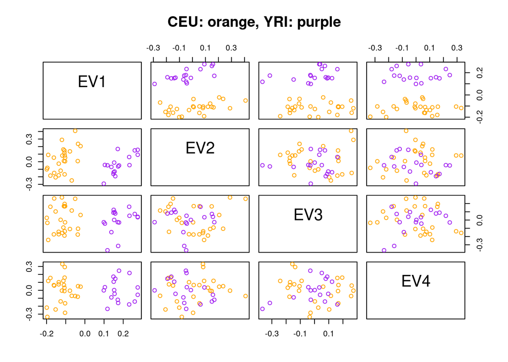

```r
# pairwise scatter plots
## create labels
labels <- paste("EV", 1:4, "\n", sep="")

## match sampleID from pca to scanID in scanAnnot
samples <- pData(scanAnnot)[match(pca$sample.id, scanAnnot$scanID),]

## create colors for each race
cols <- rep(NA, nrow(samples))
cols[samples$race == "CEU"] <- "orange"
cols[samples$race == "YRI"] <- "purple"

## plot
pairwise_scatter <- pairs(pca$eigenvect[,1:4], col=cols, labels=labels, main = "CEU: orange, YRI: purple")
```

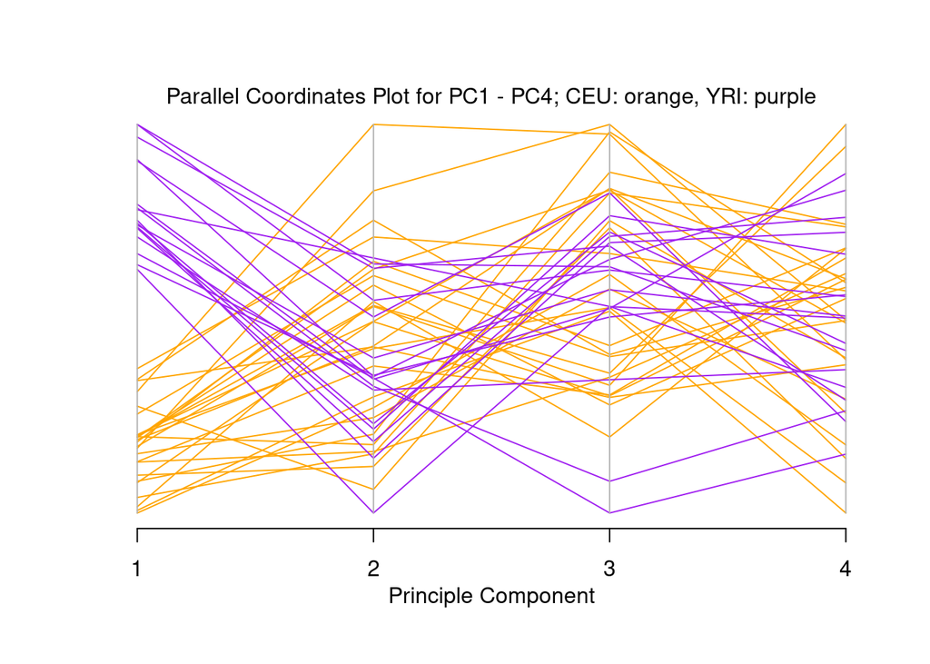

```r
# parallel coordinate plot
parcoord(pca$eigenvect[,1:4], col=cols)
mtext("Parallel Coordinates Plot for PC1 - PC4; CEU: orange, YRI: purple")
mtext("Principle Component", side = 1, line = 2)
```

## **Part 4 Report**

A parallel coordinates plot is shown below with the same colors designating the race variable.

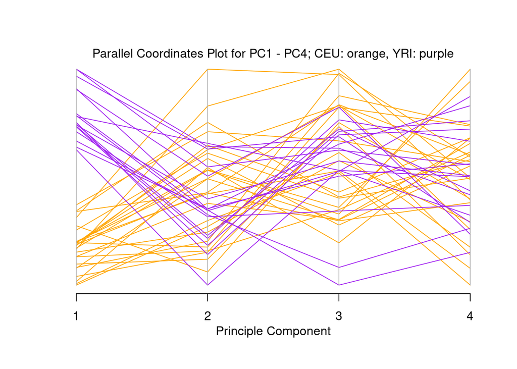

Based on the parallel coordinate plot, it appears that the first PC distinguishes between race (YRI or CEU) pretty well noted by the separation between all purple and orange threads. The remaining PCs (PC2-4) show intersections between the threads indicating those PCs do not separate the race variable as well as PC1.

## Part 5 - Duplicate Sample Discordance

Here we leverage the duplicate samples to assess genotyping errors. If the same probe often yields different genotypes for duplicate scans from the same subjects, we should probably exclude the genotypes called from that probe. We will use the function `duplicateDiscordance`.

```r
# First, we should only use high-quality scans to when we judge the probes
# (Recall that none of our scans had high missingness, so we don't have to exclude anyone in this dataset)
# We also don't want to bother testing for discordance in SNPs that are 100% missing, so we exclude those, too
scan.excl <- scanAnnot$scanID[scanAnnot$missing.e1 >= 0.05]
length(scan.excl)
snp.excl <- snpAnnot$snpID[snpAnnot$missing.n1 == 1]
length(snp.excl)

# Get the genotype data (make sure the connection to the file is closed before reopening it)
# Attach the annotation to it (note that the sex/relatedness information were "fixed" above)
#close(genoData)
showfile.gds(closeall = T, verbose = T)
genofile <- system.file("extdata", "illumina_geno.gds", package="GWASdata")
genoGDS <- GdsGenotypeReader(genofile)
genoData <- GenotypeData(genoGDS, snpAnnot=snpAnnot, scanAnnot=scanAnnot)

# Now we use the dupdisc function to calculate the discordance for each SNP (while excluding any low-quality scans and 100%-missing SNPs)
# The function returns a list of 3 objects: discordance.by.snp, discordance.by.subject, and correlation.by.subject
# discordance.by.snp has a row for each SNP, detailing the number of duplicate-pairs of scans observed for that SNP, the number of discordant gentoypes observed among those pairs, and the discordance rate
# discordance.by.subject is a list of matrices. For each subject with duplicate scans, the matrix shows the discordance between the pairs of scans (i.e., at what proportion of SNPs do two scans from the same person have different genotypes?)
# For the first subject in dupdisc$discordance.by.subject (scans 280/281), it looks like the genotypes agreed for all the SNPs
# For the second subject (scans 282/283), the discordance rate was 0.0003265839
dupdisc <- duplicateDiscordance(genoData, subjName.col="subjectID",scan.exclude=scan.excl, snp.exclude=snp.excl)
```

[output not shown]

[output not shown]

[output not shown]

[output not shown]

[output not shown]

[output not shown]

[output not shown]

[output not shown]

[output not shown]

[output not shown]

[output not shown]

[output not shown]

[output not shown]

[output not shown]

[output not shown]

[output not shown]

[output not shown]

[output not shown]

[output not shown]

[output not shown]

[output not shown]

[output not shown]

[output not shown]

[output not shown]

[output not shown]

[output not shown]

[output not shown]

[output not shown]

[output not shown]

[output not shown]

[output not shown]

[output not shown]

[output not shown]

[output not shown]

```r
names(dupdisc)
dim(dupdisc$discordance.by.snp)
head(dupdisc$discordance.by.snp)
length(dupdisc$discordance.by.subject)
dupdisc$discordance.by.subject[[1]]
dupdisc$discordance.by.subject[[2]]

# Save a summary of this information by merging the discordances into the SNP annotation
# Make sure the order of the SNPs is maintained
snpAnnot$dummy <- 1:nrow(pData(snpAnnot))
pData(snpAnnot) <- merge(x=pData(snpAnnot), y=dupdisc$discordance.by.snp[,c("snpID","discordant")], all.x=T, all.y=F)
pData(snpAnnot) <- pData(snpAnnot)[order(snpAnnot$dummy),]
```

## Part 5 - Report

Briefly explain the purpose of this step and what it means to check for discordant genotypes. Summarize the results. Be sure to answer the following:

- How many SNPs are discordant in at least one duplicate-pair?
- What’s the maximum number of discordances seen for any SNP?
- What’s the median discordance rate? What’s the maximum discordance rate?
- Decide and explicitly state the threshold, n, for filtering out SNPs based on discordance (i.e., SNPs with dupdisc$discordance.by.snp >= n will be removed)
- You may find it helpful to call the function duplicateDiscordanceProbability(npair=34). Read the documentation for this function.
- Of the SNPs that passed the missing.n2 filter (missing.n2 < 0.05), how many SNPs pass/fail the discordance threshold?
- Of the SNPs with missing.n2 < 0.05, make a histogram of the discordance rate
- Make sure you add a new column to snpAnnot called failed.dup.disc (“pass” if the SNP had >=n discordant calls, “fail” if it failed, “untested” if it was one of the high-missingness SNPs that we excluded); update the metadata

```r
# see only discordant snps
discordant_snps <- dupdisc$discordance.by.snp %>% filter(discordant != 0)
dim(discordant_snps)

# order by descending discordant pairs
discordant_snps %>% arrange(desc(discordant)) %>% head(n=25)

# get median and max discordance rate
summary(discordant_snps$discord.rate)

# help determine appropriate n threshold
duplicateDiscordanceProbability(npair=34, error.rate=0.01)

# get percentage of SNPs removed by n threshold
pbinom(1, 2*34, 0.01, F)

# number of snps
snps.keep <- snpAnnot$snpID[snpAnnot$missing.n2 < 0.05]
length(snps.keep)

# create subset
snp.excl.n2 <- snpAnnot$snpID[snpAnnot$missing.n2 >= 0.05]
dupdisc.n2 <- duplicateDiscordance(genoData, subjName.col="subjectID",scan.exclude=scan.excl, snp.exclude=snp.excl.n2)
```

[output not shown]

[output not shown]

[output not shown]

[output not shown]

[output not shown]

[output not shown]

[output not shown]

[output not shown]

[output not shown]

[output not shown]

[output not shown]

[output not shown]

[output not shown]

[output not shown]

[output not shown]

[output not shown]

[output not shown]

[output not shown]

[output not shown]

[output not shown]

[output not shown]

[output not shown]

[output not shown]

[output not shown]

[output not shown]

[output not shown]

[output not shown]

[output not shown]

[output not shown]

[output not shown]

[output not shown]

[output not shown]

[output not shown]

[output not shown]

```r
dim(dupdisc.n2$discordance.by.snp)

dupdisc.n2.m <- filter(dupdisc.n2$discordance.by.snp, discordant >= 1)
dim(dupdisc.n2.m)
head(dupdisc.n2.m)

# make histogram
dupdisc_hist <- ggplot(dupdisc.n2$discordance.by.snp, aes(x=discord.rate)) +
  geom_histogram(bins = 15, color = "aquamarine4", fill = "aquamarine") +
  labs(title = "Histogram of Discordance Rate Among SNPs with MCR < 5%",
       x = "Discordance Rate",
       y = "Count") +
  theme_minimal()


# update with 'pass'/'fail'
pData(snpAnnot) <- pData(snpAnnot) %>% mutate(failed.dup.disc = ifelse(missing.n1 == 1, "untested", ifelse(discordant >= 1, "pass", "fail")))

# check
pData(snpAnnot) %>% arrange(desc(discordant)) %>% head()

# update metadata descriptions
varMetadata(snpAnnot)["failed.dup.disc", "labelDescription"] <- paste("'pass' if the SNP had >=1 discordant calls, 'fail' if it failed, 'untested' if it was one of the high-missingness SNPs that was excluded")
```

## **Part 5 Report**

There are 25 SNPs that are discordant in at least one duplicate pair. The maximum number of discordances for a SNP is 2. The median discordance rate is 3% while the maximum is 7%. A discordance rate threshold of >= 1 discordant calls was implemented as this threshold retains >99% of SNPs with an error rate < 10^-3 while removing 14.8% of SNPs with an error rate > 10^-2. This threshold eliminates 21 SNPs. There are 3,300 total SNPs in the dataset. After filtering out 205 SNPs where missing.n2 was 5% or higher, there are 3,095 SNPs remaining. Of the remaining 3,095 SNPs, 21 fail the discordance threshold of >= 1, leaving 3,074 SNPs remaining for downstream analyses. A histogram of the remaining SNPs is shown below.

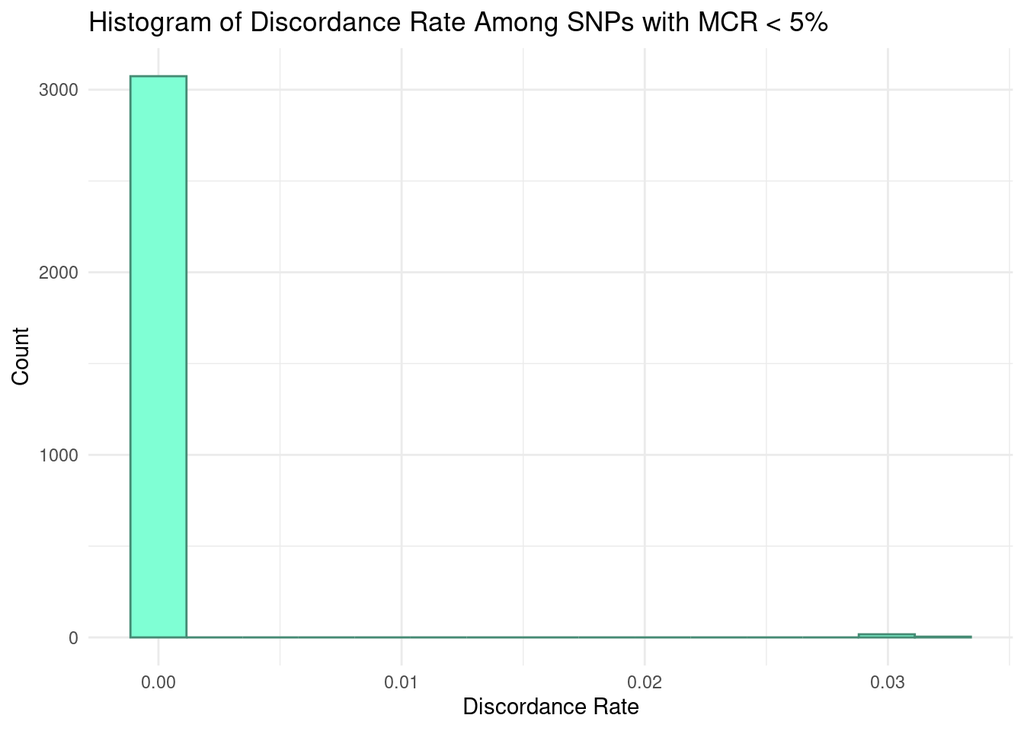

```r
dupdisc_hist
```

## Part 6 - Hardy-Weinberg Equilibrium (HWE) testing

Deviations from HWE can indicate poor genotyping. Here you will appropriately test for departures from HWE in the data using `exactHWE` (which applies Fisher’s exact test).

```r
# The test we'll use for HWE will assume independent observations
# Therefore we should include only one scan from each subject
# We should also include only "founders" (for this example, that means excluding the children, whose genotypes aren't independent of their parents')
# The nonfounders are the individuals who have a mother or father in the pedigree
head(pData(scanAnnot)[,c("father", "mother")])
nonfounders <- scanAnnot$father != 0 & scanAnnot$mother != 0
table(nonfounders)

# HWE is sensitive to population stratification (A SNP can be in HWE in each of two populations, but out of HWE in the combined population)
# Therefore in this example we'll focus on HWE in just one population group, the "CEU" group
# So we'll exclude populations other than CEU, nonfounders, and duplicates (recall tha that the "duplicated" variable was defined to include the scan with better missingness for each subject)
scan.excl <- scanAnnot$scanID[scanAnnot$race != "CEU" | nonfounders | scanAnnot$duplicated]
length(scan.excl)

# Now we use exactHWE to calculate HWE statistics
# We do this separately for the sex chromosomes
# exactHWE takes snpStart/snpEnd arguments; we use these to identify the indices corresponding to autosomal/sex chromosome SNPs
# We use the scan.exclude argument to exclude non-CEU, non-founders, and duplicates
# exactHWE has returned a data frame of HWE statistics for each SNP; read the help page to see what the columns are
# Attach the two data frames
chr <- getChromosome(genoData)
auto <- range(which(chr %in% 1:22))
X <- range(which(chr == 23))
hwe <- exactHWE(genoData, scan.exclude=scan.excl, snpStart=auto[1], snpEnd=auto[2])
```

```
## Beginning Calculations...
```

```
## Block 1 of 1 Completed - 0.01686 secs
```

```r
hweX <- exactHWE(genoData, scan.exclude=scan.excl, snpStart=X[1], snpEnd=X[2])
```

```
## Beginning Calculations...
```

```
## Block 1 of 1 Completed - 0.002305 secs
```

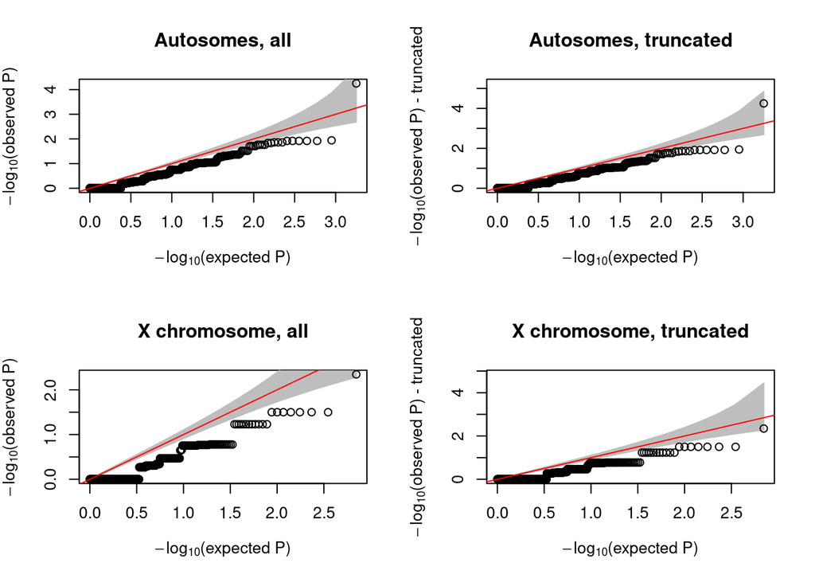

```r
hwe <- rbind(hwe, hweX)
names(hwe)
#close(genoData)

# Check on sample sizes for autosomes
# ... and for the X chromosome
# Notice there are some missing p-values for the autosomes
# ... and for X
# We can view some of the genotype counts
# The first SNP appears to be 100% missing, and the second is monomorphic (i.e., MAF=0)
# (recall that we didn't filter out SNPs here)
hwe$N <- hwe$nAA + hwe$nAB + hwe$nBB
summary(hwe$N[is.element(hwe$chr,1:22)])
summary(hwe$N[is.element(hwe$chr,23)])
hwe$pval[1:10]
sum(is.na(hwe$pval[hwe$chr == 23]))
head(hwe[, c("nAA", "nAB", "nBB")])

# Now we want to inspect deviation from HWE
# We can use Q-Q plots to help with this
# We should exclude monomorphic SNPs
# Only keep the autosomal SNPs for first plot
# Double-check that there are no missing p-values remaining
hwe.0 <- hwe[hwe$MAF > 0,]
dim(hwe.0)
pval <- hwe.0$pval[is.element(hwe.0$chr, 1:22)]
length(pval)
pval <- pval[!is.na(pval)]
length(pval)

# Similarly, get the p-values for the X-chromosome
pval.x <- hwe.0$pval[is.element(hwe.0$chr, 23)]
length(pval.x)
pval.x <- pval.x[!is.na(pval.x)]
length(pval.x)
```

## Part 6 - Report

Briefly explain the purpose of HWE testing. In describing your results for this step, answer the following:

- How do you choose what subjects to include for HWE testing? How many were used here?
- Interpret the Q-Q plots. Do any SNPs appear to be strongly out of HWE? Which SNPs? What are the lowest p-values?
- For the autosomal SNPs, make a plot of -log10(p-value) vs MAF. Make another such plot for the X chromosome.
- What p-value will you use for filtering our SNPs with low HWE? Of the SNPs with missing.n2 < 0.05, how many will be retained/removed?
- Add the HWE p-values to the SNP annotation (and update the metadata)

```r
# autosomal -log10(p-value) vs MAF
pvmaf <- ggplot(hwe.0, aes(x=MAF, y=-log10(pval))) +
  geom_point(color = "darkorchid", alpha = 0.2, size = 3) +
  labs(title = "-Log10(p) vs. MAF for Autosomal SNPs",
       x = "MAF",
       y = "-log10(p)") +
  theme_minimal()

# x -log10(p-value) vs MAF
pvmafx <- ggplot(hweX, aes(x=MAF, y=-log10(pval))) +
  geom_point(color = "deeppink", alpha = 0.2, size = 3) +
  labs(title = "-Log10(p) vs. MAF for X Chromosome SNPs",
       x = "MAF",
       y = "-log10(p)") +
  theme_minimal()

# filter out low HWE
goodsnps <- pData(snpAnnot) %>% filter(missing.n2 < 0.05)
dim(goodsnps) #3095 good snps
head(goodsnps)

# merge all into one df
goodsnps_hwe <- merge(goodsnps, hwe)
head(goodsnps_hwe)

# filter
goodsnps_hwe %>% filter(pval < 0.0001) %>% head()

# add column
snpAnnot$HWE_pval <- "NA"

# df of just snpID and pval
snp_pval <- goodsnps_hwe[,c("snpID", "pval")]
dim(snp_pval)

# update pvals
pData(snpAnnot) <- merge(pData(snpAnnot), snp_pval, by="snpID")

# update metadata
varMetadata(snpAnnot)["HWE_pval", "labelDescription"] <- paste("P-value obtained from Fisher's exact test where duplicates, nonfounders, non-CEU race, and high-missingness SNPs were excluded from analyses; excluded SNPs have a value of 'NA'.")

# find lowest p value on x
hweX %>% arrange(pval) %>% head()
```

## **Part 6 Report**

The qqplots for autosomal SNPs show one SNP that has a very small p-value. This could be due to true, significant association with the phenotype, or it could be that the SNP is out of HWE. This SNP (snpID 1015218) shows a p-value of 5.62x10^-5.

The X chromosome qqplots also have one potential outlier. This SNP (snpID 1056077) has a p-value of 4.5x10^-3. It is unlikely that this SNP is out of HWE as it does not meet the suggested HWE threshold of 1.0x10^-4.

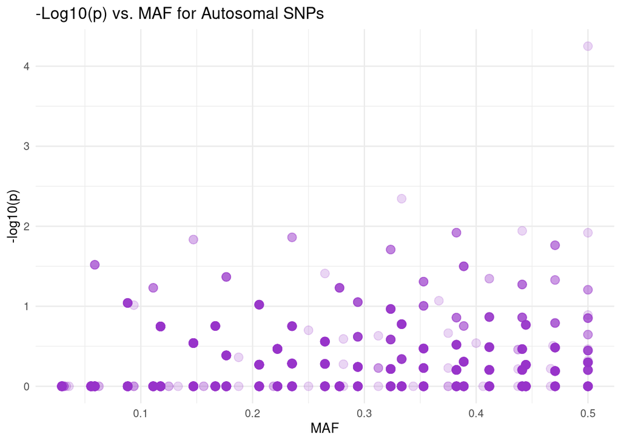

```r
pvmaf
```

For X chromosome SNPs, the same plot is below.

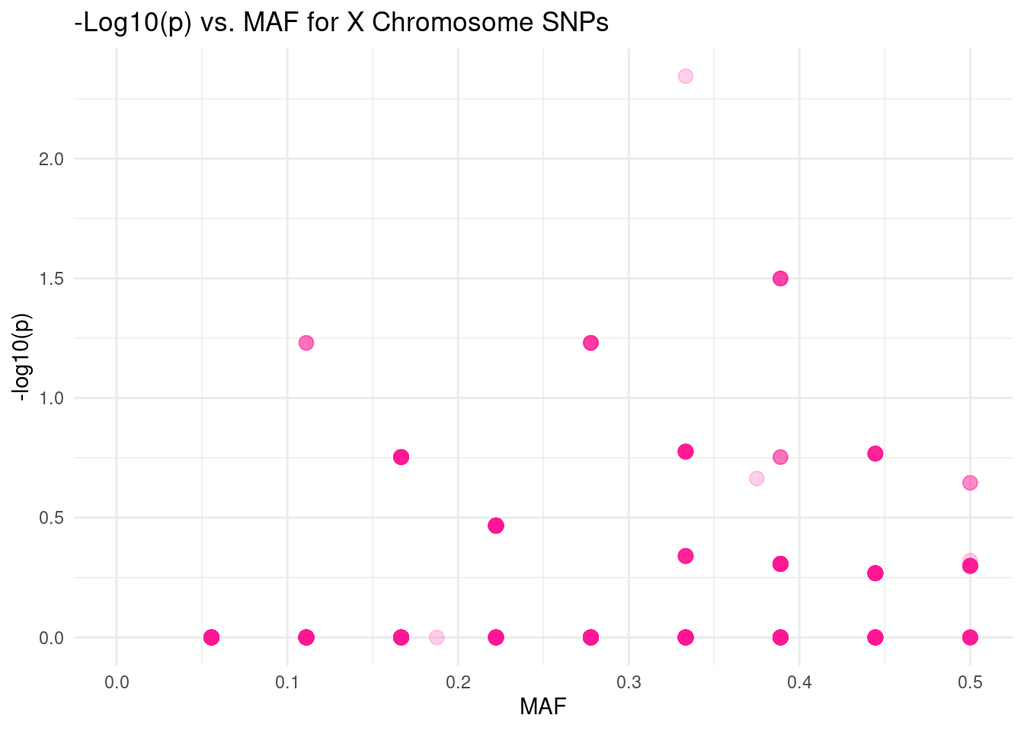

```r
pvmafx
```

The threshold for p-value will be 1.0x10^-4. After filtering by this p-value threshold, only 1 SNP is removed (snpID = 1015218) from those with low missingness leaving 3,073 SNPs remaining in the analyses.